# Exploratory Analysis

### 0. Setup

Reading packages

```r
library(readxl)
library(ggplot2)
library(data.table)
library(Hmisc)
library(dplyr)
library(tidyr)
library(stringr)
library(binom)
library(gridExtra)
library(grid)
```

Creating file paths

```r
if(Sys.info()["user"]=="JVARGH7"){
  path_ic_documentation <- "C:/code/support/interstitial_cystitis/documentation"
  path_ic_data <- "C:/Cloud/OneDrive - Emory University/Papers/Interstitial Cystitis/data"
  path_ic_save <- "C:/Cloud/OneDrive - Emory University/Papers/Interstitial Cystitis/working"
}
```

### 1. Data Cleaning

Reading the data into R

```r
ic <- readxl::read_xlsx(paste0(path_ic_data,"/De-identified covariates data.xlsx"))
```

Renaming columns: The column names were changed to make it suitable for analysis

```r
colnames(ic) <- c("id","cases",
                  "age_last_visit","gender","race","smoking",
                  "elmiron","hydroxyzine","tca","gabapentin","hydroxychloroquine",
                  "cyclobenzaprine","methenamine","phenazopyridine","oxybutynin")
ic <- ic[!is.na(ic$id),]
```

Labeling different columns

```r
ic$cases <- as.factor(ic$cases)
levels(ic$cases) <- c("1 Definite","2 Possibly", "3 Not", "4 No images")
table(ic$cases,useNA = "always")
```

```
##
##  1 Definite  2 Possibly       3 Not 4 No images        <NA>
##          14          11          48         143           0
```

```r
ic$gender <- as.factor(ic$gender)
levels(ic$gender) <- c("1 Male", "2 Female")
table(ic$gender, useNA= "always")
```

```
##
##   1 Male 2 Female     <NA>
##      192       24        0
```

```r
ic$race <- as.factor(ic$race)
levels(ic$race) <- c("1 White","2 Black", "3 Other")
table(ic$race,useNA = "always")
```

```
##
## 1 White 2 Black 3 Other    <NA>
##     150      47      19       0
```

```r
ic$smoking <- as.factor(ic$smoking)
levels(ic$smoking) <- c("1 Never", "2 Current", "3 Former")
table(ic$smoking,useNA = "always")
```

```
##
##   1 Never 2 Current  3 Former      <NA>
##       155         5        47         9
```

```r
ic$elmiron <- with(ic,ifelse(!is.na(elmiron),1,0))
ic$hydroxyzine <- with(ic,ifelse(!is.na(hydroxyzine),1,0))
ic$tca <- with(ic,ifelse(!is.na(tca),1,0))
ic$gabapentin <- with(ic,ifelse(!is.na(gabapentin),1,0))
ic$hydroxychloroquine <- with(ic,ifelse(!is.na(hydroxychloroquine),1,0))
ic$cyclobenzaprine <- with(ic,ifelse(!is.na(cyclobenzaprine),1,0))
ic$methenamine <- with(ic,ifelse(!is.na(methenamine),1,0))
ic$phenazopyridine <- with(ic,ifelse(!is.na(phenazopyridine),1,0))
ic$oxybutynin <- with(ic,ifelse(!is.na(oxybutynin),1,0))

ic <- ic %>% mutate_at(c("elmiron","hydroxyzine",
                         "tca","gabapentin","hydroxychloroquine",
                         "cyclobenzaprine","methenamine",
                         "phenazopyridine","oxybutynin"),
                       funs(factor(.,labels=c("no","yes"))))
```

Generating Summary Statistics: The variable ID has been ignored.

```r
describe(ic %>% select(-id))
```

```
## ic %>% select(-id)
##
##  14  Variables      216  Observations
## ---------------------------------------------------------------------------
## cases
##        n  missing distinct
##      216        0        4
##
## Value       1 Definite  2 Possibly       3 Not 4 No images
## Frequency           14          11          48         143
## Proportion       0.065       0.051       0.222       0.662
## ---------------------------------------------------------------------------
## age_last_visit
##        n  missing distinct     Info     Mean      Gmd      .05      .10
##      216        0       61    0.999    61.26    17.13    36.00    40.00
##      .25      .50      .75      .90      .95
##    50.75    63.00    72.00    79.50    84.00
##
## lowest : 24 25 28 29 31, highest: 86 87 88 89 90
## ---------------------------------------------------------------------------
## gender
##        n  missing distinct
##      216        0        2
##
## Value        1 Male 2 Female
## Frequency       192       24
## Proportion    0.889    0.111
## ---------------------------------------------------------------------------
## race
##        n  missing distinct
##      216        0        3
##
## Value      1 White 2 Black 3 Other
## Frequency      150      47      19
## Proportion   0.694   0.218   0.088
## ---------------------------------------------------------------------------
## smoking
##        n  missing distinct
##      207        9        3
##
```

[output cut: 61 more lines]

```
##        n  missing distinct
##      216        0        2
##
## Value         no   yes
## Frequency    160    56
## Proportion 0.741 0.259
## ---------------------------------------------------------------------------
## oxybutynin
##        n  missing distinct
##      216        0        2
##
## Value         no   yes
## Frequency    186    30
## Proportion 0.861 0.139
## ---------------------------------------------------------------------------
```

### 2. 1,2 vs 3,4

#### A. Hypothesis Tests

```r
ic$outcome <- with(ic, as.factor(ifelse(cases %in% c("1 Definite", "2 Possibly"),"yes","no")))
table(ic$outcome,useNA="always")
```

```
##
##   no  yes <NA>
##  191   25    0
```

##### Summary for Cases (Outcome = Yes)

```r
describe(ic %>% filter(outcome=="yes") %>% select(-id))
```

```
## ic %>% filter(outcome == "yes") %>% select(-id)
##
##  15  Variables      25  Observations
## ---------------------------------------------------------------------------
## cases
##        n  missing distinct
##       25        0        2
##
## Value      1 Definite 2 Possibly
## Frequency          14         11
## Proportion       0.56       0.44
## ---------------------------------------------------------------------------
## age_last_visit
##        n  missing distinct     Info     Mean      Gmd      .05      .10
##       25        0       17    0.993    61.92    14.01     39.2     45.6
##      .25      .50      .75      .90      .95
##     57.0     63.0     68.0     77.0     77.0
##
## Value        37   38   44   48   53   57   60   61   63   64   65   66
## Frequency     1    1    1    2    1    1    1    4    2    1    2    1
## Proportion 0.04 0.04 0.04 0.08 0.04 0.04 0.04 0.16 0.08 0.04 0.08 0.04
##
## Value        68   72   75   77   87
## Frequency     1    1    1    3    1
## Proportion 0.04 0.04 0.04 0.12 0.04
## ---------------------------------------------------------------------------
## gender
##        n  missing distinct
##       25        0        2
##
## Value        1 Male 2 Female
## Frequency        22        3
## Proportion     0.88     0.12
## ---------------------------------------------------------------------------
## race
##        n  missing distinct
##       25        0        3
##
## Value      1 White 2 Black 3 Other
## Frequency       18       2       5
```

[output cut: 75 more lines]

```
##        n  missing distinct
##       25        0        2
##
## Value        no  yes
## Frequency    21    4
## Proportion 0.84 0.16
## ---------------------------------------------------------------------------
## outcome
##        n  missing distinct    value
##       25        0        1      yes
##
## Value      yes
## Frequency   25
## Proportion   1
## ---------------------------------------------------------------------------
```

##### Summary for Non-cases (Outcome = No)

```r
describe(ic %>% filter(outcome=="no") %>% select(-id))
```

```
## ic %>% filter(outcome == "no") %>% select(-id)
##
##  15  Variables      191  Observations
## ---------------------------------------------------------------------------
## cases
##        n  missing distinct
##      191        0        2
##
## Value            3 Not 4 No images
## Frequency           48         143
## Proportion       0.251       0.749
## ---------------------------------------------------------------------------
## age_last_visit
##        n  missing distinct     Info     Mean      Gmd      .05      .10
##      191        0       60    0.999    61.18    17.54     36.0     40.0
##      .25      .50      .75      .90      .95
##     50.0     64.0     72.5     80.0     84.0
##
## lowest : 24 25 28 29 31, highest: 86 87 88 89 90
## ---------------------------------------------------------------------------
## gender
##        n  missing distinct
##      191        0        2
##
## Value        1 Male 2 Female
## Frequency       170       21
## Proportion     0.89     0.11
## ---------------------------------------------------------------------------
## race
##        n  missing distinct
##      191        0        3
##
## Value      1 White 2 Black 3 Other
## Frequency      132      45      14
## Proportion   0.691   0.236   0.073
## ---------------------------------------------------------------------------
## smoking
##        n  missing distinct
##      182        9        3
##
```

[output cut: 69 more lines]

```
##        n  missing distinct
##      191        0        2
##
## Value         no   yes
## Frequency    165    26
## Proportion 0.864 0.136
## ---------------------------------------------------------------------------
## outcome
##        n  missing distinct    value
##      191        0        1       no
##
## Value       no
## Frequency  191
## Proportion   1
## ---------------------------------------------------------------------------
```

##### a. Socio-demographics

```r
chisq.test(ic$outcome,ic$gender)
```

```
##
##  Pearson's Chi-squared test with Yates' continuity correction
##
## data:  ic$outcome and ic$gender
## X-squared = 5.8136e-31, df = 1, p-value = 1
```

```r
chisq.test(ic$outcome,ic$gender)$expected
```

```
##           ic$gender
## ic$outcome    1 Male  2 Female
##        no  169.77778 21.222222
##        yes  22.22222  2.777778
```

```r
fisher.test(ic$outcome,ic$gender)
```

```
##
##  Fisher's Exact Test for Count Data
##
## data:  ic$outcome and ic$gender
## p-value = 0.7459
## alternative hypothesis: true odds ratio is not equal to 1
## 95 percent confidence interval:
##  0.1950689 4.1704231
## sample estimates:
## odds ratio
##   1.103402
```

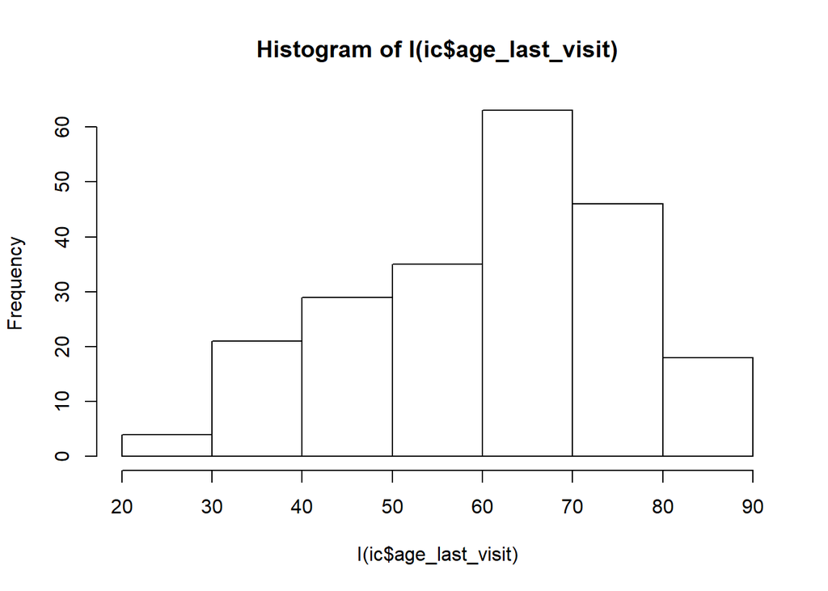

```r
hist(I(ic$age_last_visit))
```

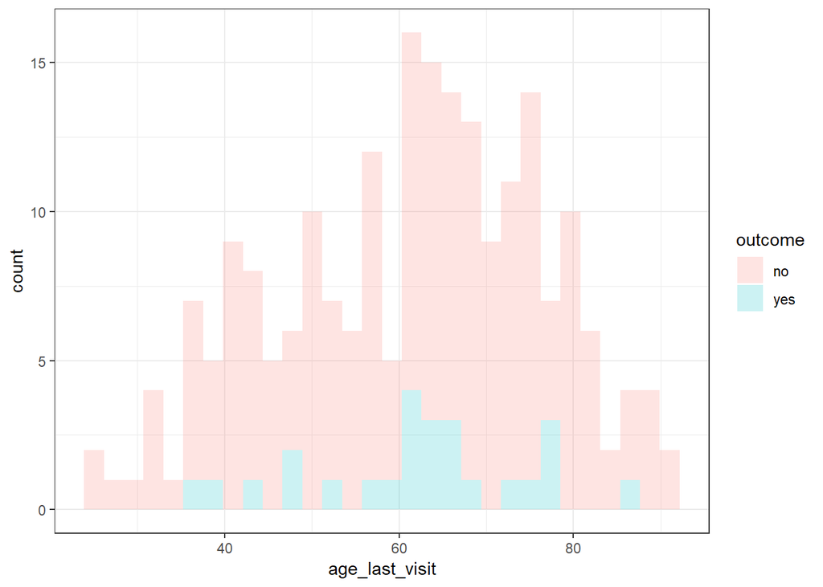

```r
ggplot(data=ic,aes(x=age_last_visit,group=outcome,fill=outcome)) + geom_histogram(alpha=0.2) + theme_bw()
```

There is slight deviation from normality for Age in Last Visit for those who had Outcome = Yes. This is likely due to sample size issues.

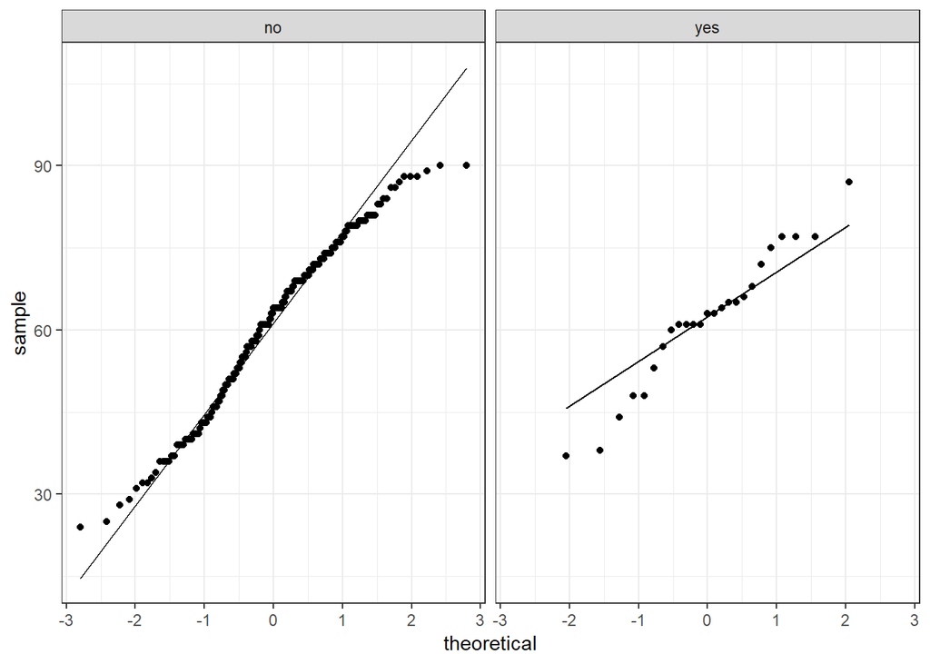

```r
ggplot(data=ic,aes(sample=age_last_visit)) + geom_qq() + geom_qq_line() + facet_grid(~outcome) + theme_bw()
```

Levene’s test for Equality of variance does not reject the null hypothesis (Variances are equal)

```r
car::leveneTest(age_last_visit~outcome,data=ic)
```

```
## Levene's Test for Homogeneity of Variance (center = median)
##        Df F value  Pr(>F)
## group   1   3.414 0.06602 .
##       214
## ---
## Signif. codes:  0 '***' 0.001 '**' 0.01 '*' 0.05 '.' 0.1 ' ' 1
```

We will use Independent Two-sample T-test (Pooled) We do not reject the null hypothesis that age at last visit is different across the outcome groups

```r
t.test(age_last_visit~outcome,data=ic,var.equal=TRUE)
```

```
##
##  Two Sample t-test
##
## data:  age_last_visit by outcome
## t = -0.23212, df = 214, p-value = 0.8167
## alternative hypothesis: true difference in means is not equal to 0
## 95 percent confidence interval:
##  -7.042806  5.558827
## sample estimates:
##  mean in group no mean in group yes
##          61.17801          61.92000
```

Wilcoxon Rank Sum test confirms the above result.

```r
wilcox.test(age_last_visit~outcome,data=ic,var.equal=TRUE)
```

```
##
##  Wilcoxon rank sum test with continuity correction
##
## data:  age_last_visit by outcome
## W = 2385, p-value = 0.9946
## alternative hypothesis: true location shift is not equal to 0
```

##### We will use the results from Fisher’s exact tests

```r
chisq.test(ic$outcome,ic$race)
```

```
##
##  Pearson's Chi-squared test
##
## data:  ic$outcome and ic$race
## X-squared = 6.5209, df = 2, p-value = 0.03837
```

```r
chisq.test(ic$outcome,ic$race)$expected
```

```
##           ic$race
## ic$outcome   1 White   2 Black   3 Other
##        no  132.63889 41.560185 16.800926
##        yes  17.36111  5.439815  2.199074
```

```r
#Use Fisher's Exact since Yates' correction was applied
fisher.test(ic$outcome,ic$race)
```

```
##
##  Fisher's Exact Test for Count Data
##
## data:  ic$outcome and ic$race
## p-value = 0.04212
## alternative hypothesis: two.sided
```

NA values are ignored in chi-square. We will test missingness in univariate logistic

```r
chisq.test(ic$outcome,ic$smoking)
```

```
##
##  Pearson's Chi-squared test
##
## data:  ic$outcome and ic$smoking
## X-squared = 0.87804, df = 2, p-value = 0.6447
```

```r
chisq.test(ic$outcome,ic$smoking)$observed
```

```
##           ic$smoking
## ic$outcome 1 Never 2 Current 3 Former
##        no      135         5       42
##        yes      20         0        5
```

```r
chisq.test(ic$outcome,ic$smoking)$expected
```

```
##           ic$smoking
## ic$outcome   1 Never 2 Current  3 Former
##        no  136.28019 4.3961353 41.323671
##        yes  18.71981 0.6038647  5.676329
```

```r
#Use Fisher's Exact since Yates' correction was applied
fisher.test(ic$outcome,ic$smoking)
```

```
##
##  Fisher's Exact Test for Count Data
##
## data:  ic$outcome and ic$smoking
## p-value = 0.8977
## alternative hypothesis: two.sided
```

##### b. Pharmaceuticals

```r
chisq.test(ic$outcome,ic$elmiron)
```

```
##
##  Pearson's Chi-squared test with Yates' continuity correction
##
## data:  ic$outcome and ic$elmiron
## X-squared = 19.423, df = 1, p-value = 1.047e-05
```

```r
#Printing expected counts to check
chisq.test(ic$outcome,ic$elmiron)$expected
```

```
##           ic$elmiron
## ic$outcome        no      yes
##        no  112.30093 78.69907
##        yes  14.69907 10.30093
```

```r
#Use Fisher's Exact since Yates' correction was applied
fisher.test(ic$outcome,ic$elmiron)
```

```
##
##  Fisher's Exact Test for Count Data
##
## data:  ic$outcome and ic$elmiron
## p-value = 4.844e-06
## alternative hypothesis: true odds ratio is not equal to 1
## 95 percent confidence interval:
##   3.002994 39.238378
## sample estimates:
## odds ratio
##   9.399577
```

```r
chisq.test(ic$outcome,ic$hydroxyzine)
```

```
##
##  Pearson's Chi-squared test with Yates' continuity correction
##
## data:  ic$outcome and ic$hydroxyzine
## X-squared = 1.6918, df = 1, p-value = 0.1934
```

```r
#Printing expected counts to check
chisq.test(ic$outcome,ic$hydroxyzine)$expected
```

```
##           ic$hydroxyzine
## ic$outcome        no       yes
##        no  145.90278 45.097222
##        yes  19.09722  5.902778
```

```r
#Use Fisher's Exact since Yates' correction was applied
fisher.test(ic$outcome,ic$hydroxyzine)
```

```
##
##  Fisher's Exact Test for Count Data
##
## data:  ic$outcome and ic$hydroxyzine
## p-value = 0.1355
## alternative hypothesis: true odds ratio is not equal to 1
## 95 percent confidence interval:
##  0.7202691 5.1919016
## sample estimates:
## odds ratio
##   1.988336
```

```r
chisq.test(ic$outcome,ic$tca)
```

```
##
##  Pearson's Chi-squared test with Yates' continuity correction
##
## data:  ic$outcome and ic$tca
## X-squared = 3.7256e-29, df = 1, p-value = 1
```

```r
#Printing expected counts to check
chisq.test(ic$outcome,ic$tca)$expected
```

```
##           ic$tca
## ic$outcome        no       yes
##        no  137.94444 53.055556
##        yes  18.05556  6.944444
```

```r
#Use Fisher's Exact since Yates' correction was applied
fisher.test(ic$outcome,ic$tca)
```

```
##
##  Fisher's Exact Test for Count Data
##
## data:  ic$outcome and ic$tca
## p-value = 1
## alternative hypothesis: true odds ratio is not equal to 1
## 95 percent confidence interval:
##  0.3374742 2.7238132
## sample estimates:
## odds ratio
##    1.01252
```

```r
chisq.test(ic$outcome,ic$gabapentin)
```

```
##
##  Pearson's Chi-squared test with Yates' continuity correction
##
## data:  ic$outcome and ic$gabapentin
## X-squared = 0.93996, df = 1, p-value = 0.3323
```

```r
#Printing expected counts to check
chisq.test(ic$outcome,ic$gabapentin)$expected
```

```
##           ic$gabapentin
## ic$outcome        no       yes
##        no  116.72222 74.277778
##        yes  15.27778  9.722222
```

```r
#Use Fisher's Exact since Yates' correction was applied
fisher.test(ic$outcome,ic$gabapentin)
```

```
##
##  Fisher's Exact Test for Count Data
##
## data:  ic$outcome and ic$gabapentin
## p-value = 0.28
## alternative hypothesis: true odds ratio is not equal to 1
## 95 percent confidence interval:
##  0.1941332 1.5342382
## sample estimates:
## odds ratio
##  0.5771503
```

```r
chisq.test(ic$outcome,ic$hydroxychloroquine)
```

```
##
##  Pearson's Chi-squared test with Yates' continuity correction
##
## data:  ic$outcome and ic$hydroxychloroquine
## X-squared = 8.1249e-29, df = 1, p-value = 1
```

```r
#Printing expected counts to check
chisq.test(ic$outcome,ic$hydroxychloroquine)$expected
```

```
##           ic$hydroxychloroquine
## ic$outcome        no      yes
##        no  178.62037 12.37963
##        yes  23.37963  1.62037
```

```r
#Use Fisher's Exact since Yates' correction was applied
fisher.test(ic$outcome,ic$hydroxychloroquine)
```

```
##
##  Fisher's Exact Test for Count Data
##
## data:  ic$outcome and ic$hydroxychloroquine
## p-value = 0.6683
## alternative hypothesis: true odds ratio is not equal to 1
## 95 percent confidence interval:
##  0.132760 6.404359
## sample estimates:
## odds ratio
##   1.295398
```

```r
chisq.test(ic$outcome,ic$cyclobenzaprine)
```

```
##
##  Pearson's Chi-squared test with Yates' continuity correction
##
## data:  ic$outcome and ic$cyclobenzaprine
## X-squared = 0.63983, df = 1, p-value = 0.4238
```

```r
#Printing expected counts to check
chisq.test(ic$outcome,ic$cyclobenzaprine)$expected
```

```
##           ic$cyclobenzaprine
## ic$outcome        no       yes
##        no  145.90278 45.097222
##        yes  19.09722  5.902778
```

```r
#Use Fisher's Exact since Yates' correction was applied
fisher.test(ic$outcome,ic$cyclobenzaprine)
```

```
##
##  Fisher's Exact Test for Count Data
##
## data:  ic$outcome and ic$cyclobenzaprine
## p-value = 0.3188
## alternative hypothesis: true odds ratio is not equal to 1
## 95 percent confidence interval:
##  0.5633981 4.2846488
## sample estimates:
## odds ratio
##   1.615736
```

```r
chisq.test(ic$outcome,ic$methenamine)
```

```
##
##  Pearson's Chi-squared test with Yates' continuity correction
##
## data:  ic$outcome and ic$methenamine
## X-squared = 3.2232e-30, df = 1, p-value = 1
```

```r
#Printing expected counts to check
chisq.test(ic$outcome,ic$methenamine)$expected
```

```
##           ic$methenamine
## ic$outcome        no       yes
##        no  153.86111 37.138889
##        yes  20.13889  4.861111
```

```r
#Use Fisher's Exact since Yates' correction was applied
fisher.test(ic$outcome,ic$methenamine)
```

```
##
##  Fisher's Exact Test for Count Data
##
## data:  ic$outcome and ic$methenamine
## p-value = 1
## alternative hypothesis: true odds ratio is not equal to 1
## 95 percent confidence interval:
##  0.2861799 3.1128483
## sample estimates:
## odds ratio
##    1.04035
```

```r
chisq.test(ic$outcome,ic$phenazopyridine)
```

```
##
##  Pearson's Chi-squared test with Yates' continuity correction
##
## data:  ic$outcome and ic$phenazopyridine
## X-squared = 0.22691, df = 1, p-value = 0.6338
```

```r
#Printing expected counts to check
chisq.test(ic$outcome,ic$phenazopyridine)$expected
```

```
##           ic$phenazopyridine
## ic$outcome        no       yes
##        no  141.48148 49.518519
##        yes  18.51852  6.481481
```

```r
#Use Fisher's Exact since Yates' correction was applied
fisher.test(ic$outcome,ic$phenazopyridine)
```

```
##
##  Fisher's Exact Test for Count Data
##
## data:  ic$outcome and ic$phenazopyridine
## p-value = 0.6289
## alternative hypothesis: true odds ratio is not equal to 1
## 95 percent confidence interval:
##  0.1914676 2.0208360
## sample estimates:
## odds ratio
##  0.6873864
```

```r
chisq.test(ic$outcome,ic$oxybutynin)
```

```
##
##  Pearson's Chi-squared test with Yates' continuity correction
##
## data:  ic$outcome and ic$oxybutynin
## X-squared = 0.00029184, df = 1, p-value = 0.9864
```

```r
#Printing expected counts to check
chisq.test(ic$outcome,ic$oxybutynin)$expected
```

```
##           ic$oxybutynin
## ic$outcome        no       yes
##        no  164.47222 26.527778
##        yes  21.52778  3.472222
```

```r
#Use Fisher's Exact since Yates' correction was applied
fisher.test(ic$outcome,ic$oxybutynin)
```

```
##
##  Fisher's Exact Test for Count Data
##
## data:  ic$outcome and ic$oxybutynin
## p-value = 0.7588
## alternative hypothesis: true odds ratio is not equal to 1
## 95 percent confidence interval:
##  0.2791821 3.9982202
## sample estimates:
## odds ratio
##   1.207674
```

#### B. Univariate Logistic

##### a. Socio-demographics

```r
summary(glm(relevel(ic$outcome, ref = "no") ~ race,
            data=ic,family="binomial"))
```

```
##
## Call:
## glm(formula = relevel(ic$outcome, ref = "no") ~ race, family = "binomial",
##     data = ic)
##
## Deviance Residuals:
##     Min       1Q   Median       3Q      Max
## -0.7815  -0.5056  -0.5056  -0.2949   2.5128
##
## Coefficients:
##             Estimate Std. Error z value Pr(>|z|)
## (Intercept)  -1.9924     0.2513  -7.930  2.2e-15 ***
## race2 Black  -1.1211     0.7650  -1.466    0.143
## race3 Other   0.9628     0.5784   1.665    0.096 .
## ---
## Signif. codes:  0 '***' 0.001 '**' 0.01 '*' 0.05 '.' 0.1 ' ' 1
##
## (Dispersion parameter for binomial family taken to be 1)
##
##     Null deviance: 154.81  on 215  degrees of freedom
## Residual deviance: 148.52  on 213  degrees of freedom
## AIC: 154.52
##
## Number of Fisher Scoring iterations: 5
```

```r
summary(glm(relevel(ic$outcome, ref = "no") ~ age_last_visit,
            data=ic,family="binomial"))
```

```
##
## Call:
## glm(formula = relevel(ic$outcome, ref = "no") ~ age_last_visit,
##     family = "binomial", data = ic)
##
## Deviance Residuals:
##     Min       1Q   Median       3Q      Max
## -0.5186  -0.5036  -0.4956  -0.4817   2.1115
##
## Coefficients:
##                 Estimate Std. Error z value Pr(>|z|)
## (Intercept)    -2.238648   0.909696  -2.461   0.0139 *
## age_last_visit  0.003335   0.014304   0.233   0.8157
## ---
## Signif. codes:  0 '***' 0.001 '**' 0.01 '*' 0.05 '.' 0.1 ' ' 1
##
## (Dispersion parameter for binomial family taken to be 1)
##
##     Null deviance: 154.81  on 215  degrees of freedom
## Residual deviance: 154.75  on 214  degrees of freedom
## AIC: 158.75
##
## Number of Fisher Scoring iterations: 4
```

```r
summary(glm(relevel(ic$outcome, ref = "no") ~ gender,
            data=ic,family="binomial"))
```

```
##
## Call:
## glm(formula = relevel(ic$outcome, ref = "no") ~ gender, family = "binomial",
##     data = ic)
##
## Deviance Residuals:
##     Min       1Q   Median       3Q      Max
## -0.5168  -0.4934  -0.4934  -0.4934   2.0816
##
## Coefficients:
##                Estimate Std. Error z value Pr(>|z|)
## (Intercept)    -2.04476    0.22657  -9.025   <2e-16 ***
## gender2 Female  0.09885    0.65748   0.150     0.88
## ---
## Signif. codes:  0 '***' 0.001 '**' 0.01 '*' 0.05 '.' 0.1 ' ' 1
##
## (Dispersion parameter for binomial family taken to be 1)
##
##     Null deviance: 154.81  on 215  degrees of freedom
## Residual deviance: 154.79  on 214  degrees of freedom
## AIC: 158.79
##
## Number of Fisher Scoring iterations: 4
```

```r
summary(glm(relevel(ic$outcome, ref = "no") ~ smoking,
            data=ic,family="binomial"))
```

```
##
## Call:
## glm(formula = relevel(ic$outcome, ref = "no") ~ smoking, family = "binomial",
##     data = ic)
##
## Deviance Residuals:
##     Min       1Q   Median       3Q      Max
## -0.5256  -0.5256  -0.5256  -0.4743   2.1169
##
## Coefficients:
##                   Estimate Std. Error z value Pr(>|z|)
## (Intercept)        -1.9095     0.2396  -7.970 1.59e-15 ***
## smoking2 Current  -14.6565  1073.1090  -0.014    0.989
## smoking3 Former    -0.2187     0.5303  -0.412    0.680
## ---
## Signif. codes:  0 '***' 0.001 '**' 0.01 '*' 0.05 '.' 0.1 ' ' 1
##
## (Dispersion parameter for binomial family taken to be 1)
##
##     Null deviance: 152.54  on 206  degrees of freedom
## Residual deviance: 151.06  on 204  degrees of freedom
##   (9 observations deleted due to missingness)
## AIC: 157.06
##
## Number of Fisher Scoring iterations: 15
```

##### b. Pharmaceuticals

```r
summary(glm(relevel(ic$outcome, ref = "no") ~ elmiron,
            data=ic,family="binomial"))
```

```
##
## Call:
## glm(formula = relevel(ic$outcome, ref = "no") ~ elmiron, family = "binomial",
##     data = ic)
##
## Deviance Residuals:
##     Min       1Q   Median       3Q      Max
## -0.7337  -0.7337  -0.2530  -0.2530   2.6298
##
## Coefficients:
##             Estimate Std. Error z value Pr(>|z|)
## (Intercept)  -3.4259     0.5081  -6.743 1.55e-11 ***
## elmironyes    2.2509     0.5661   3.976 7.00e-05 ***
## ---
## Signif. codes:  0 '***' 0.001 '**' 0.01 '*' 0.05 '.' 0.1 ' ' 1
##
## (Dispersion parameter for binomial family taken to be 1)
##
##     Null deviance: 154.81  on 215  degrees of freedom
## Residual deviance: 132.79  on 214  degrees of freedom
## AIC: 136.79
##
## Number of Fisher Scoring iterations: 6
```

```r
summary(glm(relevel(ic$outcome, ref = "no") ~ hydroxyzine,
            data=ic,family="binomial"))
```

```
##
## Call:
## glm(formula = relevel(ic$outcome, ref = "no") ~ hydroxyzine,
##     family = "binomial", data = ic)
##
## Deviance Residuals:
##     Min       1Q   Median       3Q      Max
## -0.6231  -0.4517  -0.4517  -0.4517   2.1603
##
## Coefficients:
##                Estimate Std. Error z value Pr(>|z|)
## (Intercept)     -2.2314     0.2631  -8.483   <2e-16 ***
## hydroxyzineyes   0.6909     0.4518   1.529    0.126
## ---
## Signif. codes:  0 '***' 0.001 '**' 0.01 '*' 0.05 '.' 0.1 ' ' 1
##
## (Dispersion parameter for binomial family taken to be 1)
##
##     Null deviance: 154.81  on 215  degrees of freedom
## Residual deviance: 152.60  on 214  degrees of freedom
## AIC: 156.6
##
## Number of Fisher Scoring iterations: 4
```

```r
summary(glm(relevel(ic$outcome, ref = "no") ~ tca,
            data=ic,family="binomial"))
```

```
##
## Call:
## glm(formula = relevel(ic$outcome, ref = "no") ~ tca, family = "binomial",
##     data = ic)
##
## Deviance Residuals:
##     Min       1Q   Median       3Q      Max
## -0.4981  -0.4952  -0.4952  -0.4952   2.0782
##
## Coefficients:
##             Estimate Std. Error z value Pr(>|z|)
## (Intercept)  -2.0369     0.2506  -8.128 4.36e-16 ***
## tcayes        0.0125     0.4738   0.026    0.979
## ---
## Signif. codes:  0 '***' 0.001 '**' 0.01 '*' 0.05 '.' 0.1 ' ' 1
##
## (Dispersion parameter for binomial family taken to be 1)
##
##     Null deviance: 154.81  on 215  degrees of freedom
## Residual deviance: 154.81  on 214  degrees of freedom
## AIC: 158.81
##
## Number of Fisher Scoring iterations: 4
```

```r
summary(glm(relevel(ic$outcome, ref = "no") ~ gabapentin,
            data=ic,family="binomial"))
```

```
##
## Call:
## glm(formula = relevel(ic$outcome, ref = "no") ~ gabapentin, family = "binomial",
##     data = ic)
##
## Deviance Residuals:
##     Min       1Q   Median       3Q      Max
## -0.5415  -0.5415  -0.5415  -0.4172   2.2293
##
## Coefficients:
##               Estimate Std. Error z value Pr(>|z|)
## (Intercept)    -1.8458     0.2536  -7.278  3.4e-13 ***
## gabapentinyes  -0.5521     0.4692  -1.177    0.239
## ---
## Signif. codes:  0 '***' 0.001 '**' 0.01 '*' 0.05 '.' 0.1 ' ' 1
##
## (Dispersion parameter for binomial family taken to be 1)
##
##     Null deviance: 154.81  on 215  degrees of freedom
## Residual deviance: 153.34  on 214  degrees of freedom
## AIC: 157.34
##
## Number of Fisher Scoring iterations: 5
```

```r
summary(glm(relevel(ic$outcome, ref = "no") ~ hydroxychloroquine,
            data=ic,family="binomial"))
```

```
##
## Call:
## glm(formula = relevel(ic$outcome, ref = "no") ~ hydroxychloroquine,
##     family = "binomial", data = ic)
##
## Deviance Residuals:
##     Min       1Q   Median       3Q      Max
## -0.5553  -0.4917  -0.4917  -0.4917   2.0846
##
## Coefficients:
##                       Estimate Std. Error z value Pr(>|z|)
## (Intercept)            -2.0519     0.2215  -9.264   <2e-16 ***
## hydroxychloroquineyes   0.2601     0.7952   0.327    0.744
## ---
## Signif. codes:  0 '***' 0.001 '**' 0.01 '*' 0.05 '.' 0.1 ' ' 1
##
## (Dispersion parameter for binomial family taken to be 1)
##
##     Null deviance: 154.81  on 215  degrees of freedom
## Residual deviance: 154.71  on 214  degrees of freedom
## AIC: 158.71
##
## Number of Fisher Scoring iterations: 4
```

```r
summary(glm(relevel(ic$outcome, ref = "no") ~ cyclobenzaprine,
            data=ic,family="binomial"))
```

```
##
## Call:
## glm(formula = relevel(ic$outcome, ref = "no") ~ cyclobenzaprine,
##     family = "binomial", data = ic)
##
## Deviance Residuals:
##     Min       1Q   Median       3Q      Max
## -0.5842  -0.4663  -0.4663  -0.4663   2.1320
##
## Coefficients:
##                    Estimate Std. Error z value Pr(>|z|)
## (Intercept)         -2.1640     0.2561  -8.451   <2e-16 ***
## cyclobenzaprineyes   0.4822     0.4624   1.043    0.297
## ---
## Signif. codes:  0 '***' 0.001 '**' 0.01 '*' 0.05 '.' 0.1 ' ' 1
##
## (Dispersion parameter for binomial family taken to be 1)
##
##     Null deviance: 154.81  on 215  degrees of freedom
## Residual deviance: 153.77  on 214  degrees of freedom
## AIC: 157.77
##
## Number of Fisher Scoring iterations: 4
```

```r
summary(glm(relevel(ic$outcome, ref = "no") ~ methenamine,
            data=ic,family="binomial"))
```

```
##
## Call:
## glm(formula = relevel(ic$outcome, ref = "no") ~ methenamine,
##     family = "binomial", data = ic)
##
## Deviance Residuals:
##     Min       1Q   Median       3Q      Max
## -0.5035  -0.4942  -0.4942  -0.4942   2.0801
##
## Coefficients:
##                Estimate Std. Error z value Pr(>|z|)
## (Intercept)    -2.04122    0.23768  -8.588   <2e-16 ***
## methenamineyes  0.03974    0.53246   0.075    0.941
## ---
## Signif. codes:  0 '***' 0.001 '**' 0.01 '*' 0.05 '.' 0.1 ' ' 1
##
## (Dispersion parameter for binomial family taken to be 1)
##
##     Null deviance: 154.81  on 215  degrees of freedom
## Residual deviance: 154.80  on 214  degrees of freedom
## AIC: 158.8
##
## Number of Fisher Scoring iterations: 4
```

```r
summary(glm(relevel(ic$outcome, ref = "no") ~ phenazopyridine,
            data=ic,family="binomial"))
```

```
##
## Call:
## glm(formula = relevel(ic$outcome, ref = "no") ~ phenazopyridine,
##     family = "binomial", data = ic)
##
## Deviance Residuals:
##     Min       1Q   Median       3Q      Max
## -0.5168  -0.5168  -0.5168  -0.4325   2.1981
##
## Coefficients:
##                    Estimate Std. Error z value Pr(>|z|)
## (Intercept)         -1.9459     0.2390  -8.140 3.94e-16 ***
## phenazopyridineyes  -0.3765     0.5261  -0.716    0.474
## ---
## Signif. codes:  0 '***' 0.001 '**' 0.01 '*' 0.05 '.' 0.1 ' ' 1
##
## (Dispersion parameter for binomial family taken to be 1)
##
##     Null deviance: 154.81  on 215  degrees of freedom
## Residual deviance: 154.27  on 214  degrees of freedom
## AIC: 158.27
##
## Number of Fisher Scoring iterations: 5
```

```r
summary(glm(relevel(ic$outcome, ref = "no") ~ oxybutynin,
            data=ic,family="binomial"))
```

```
##
## Call:
## glm(formula = relevel(ic$outcome, ref = "no") ~ oxybutynin, family = "binomial",
##     data = ic)
##
## Deviance Residuals:
##     Min       1Q   Median       3Q      Max
## -0.5350  -0.4895  -0.4895  -0.4895   2.0886
##
## Coefficients:
##               Estimate Std. Error z value Pr(>|z|)
## (Intercept)    -2.0614     0.2317  -8.898   <2e-16 ***
## oxybutyninyes   0.1896     0.5849   0.324    0.746
## ---
## Signif. codes:  0 '***' 0.001 '**' 0.01 '*' 0.05 '.' 0.1 ' ' 1
##
## (Dispersion parameter for binomial family taken to be 1)
##
##     Null deviance: 154.81  on 215  degrees of freedom
## Residual deviance: 154.71  on 214  degrees of freedom
## AIC: 158.71
##
## Number of Fisher Scoring iterations: 4
```

From the analysis, we shall select at p<0.25 for univariate logistic, gabapentin, hydroxyzine and elmiron

#### C. Multiple Logistic

Adjusting for age, gender, race and smoking status

```r
summary(glm(relevel(ic$outcome, ref = "no") ~ race + age_last_visit + gender + smoking + elmiron,
            data=ic,family="binomial"))
```

```
##
## Call:
## glm(formula = relevel(ic$outcome, ref = "no") ~ race + age_last_visit +
##     gender + smoking + elmiron, family = "binomial", data = ic)
##
## Deviance Residuals:
##     Min       1Q   Median       3Q      Max
## -1.0281  -0.5642  -0.2803  -0.1965   2.8967
##
## Coefficients:
##                    Estimate Std. Error z value Pr(>|z|)
## (Intercept)        -4.20358    1.21086  -3.472 0.000517 ***
## race2 Black        -0.96304    0.79620  -1.210 0.226449
## race3 Other         0.51005    0.62146   0.821 0.411803
## age_last_visit      0.01494    0.01670   0.895 0.370832
## gender2 Female      0.50569    0.74312   0.680 0.496192
## smoking2 Current  -15.38706 1611.26093  -0.010 0.992381
## smoking3 Former    -0.31352    0.59106  -0.530 0.595817
## elmironyes          2.25580    0.59091   3.817 0.000135 ***
## ---
## Signif. codes:  0 '***' 0.001 '**' 0.01 '*' 0.05 '.' 0.1 ' ' 1
##
## (Dispersion parameter for binomial family taken to be 1)
##
##     Null deviance: 152.54  on 206  degrees of freedom
## Residual deviance: 125.52  on 199  degrees of freedom
##   (9 observations deleted due to missingness)
## AIC: 141.52
##
## Number of Fisher Scoring iterations: 16
```

```r
summary(glm(relevel(ic$outcome, ref = "no") ~ race + age_last_visit + gender + smoking + hydroxyzine,
            data=ic,family="binomial"))
```

```
##
## Call:
## glm(formula = relevel(ic$outcome, ref = "no") ~ race + age_last_visit +
##     gender + smoking + hydroxyzine, family = "binomial", data = ic)
##
## Deviance Residuals:
##     Min       1Q   Median       3Q      Max
## -0.9868  -0.5184  -0.4614  -0.2965   2.6147
##
## Coefficients:
##                    Estimate Std. Error z value Pr(>|z|)
## (Intercept)      -2.648e+00  9.850e-01  -2.688  0.00719 **
## race2 Black      -1.119e+00  7.823e-01  -1.431  0.15255
## race3 Other       9.507e-01  5.938e-01   1.601  0.10934
## age_last_visit    7.955e-03  1.500e-02   0.530  0.59585
## gender2 Female    2.512e-01  6.968e-01   0.360  0.71851
## smoking2 Current -1.378e+01  1.042e+03  -0.013  0.98945
## smoking3 Former   4.392e-02  5.595e-01   0.078  0.93744
## hydroxyzineyes    6.736e-01  4.767e-01   1.413  0.15763
## ---
## Signif. codes:  0 '***' 0.001 '**' 0.01 '*' 0.05 '.' 0.1 ' ' 1
##
## (Dispersion parameter for binomial family taken to be 1)
##
##     Null deviance: 152.54  on 206  degrees of freedom
## Residual deviance: 143.34  on 199  degrees of freedom
##   (9 observations deleted due to missingness)
## AIC: 159.34
##
## Number of Fisher Scoring iterations: 15
```

```r
summary(glm(relevel(ic$outcome, ref = "no") ~ race + age_last_visit + gender + smoking + gabapentin,
            data=ic,family="binomial"))
```

```
##
## Call:
## glm(formula = relevel(ic$outcome, ref = "no") ~ race + age_last_visit +
##     gender + smoking + gabapentin, family = "binomial", data = ic)
##
## Deviance Residuals:
##     Min       1Q   Median       3Q      Max
## -0.9205  -0.5495  -0.4852  -0.3263   2.5594
##
## Coefficients:
##                    Estimate Std. Error z value Pr(>|z|)
## (Intercept)      -2.189e+00  9.597e-01  -2.281   0.0225 *
## race2 Black      -9.751e-01  7.826e-01  -1.246   0.2127
## race3 Other       9.973e-01  5.892e-01   1.693   0.0905 .
## age_last_visit    5.859e-03  1.489e-02   0.394   0.6938
## gender2 Female    8.957e-02  6.880e-01   0.130   0.8964
## smoking2 Current -1.394e+01  1.043e+03  -0.013   0.9893
## smoking3 Former  -6.141e-02  5.549e-01  -0.111   0.9119
## gabapentinyes    -3.535e-01  4.837e-01  -0.731   0.4649
## ---
## Signif. codes:  0 '***' 0.001 '**' 0.01 '*' 0.05 '.' 0.1 ' ' 1
##
## (Dispersion parameter for binomial family taken to be 1)
##
##     Null deviance: 152.54  on 206  degrees of freedom
## Residual deviance: 144.71  on 199  degrees of freedom
##   (9 observations deleted due to missingness)
## AIC: 160.71
##
## Number of Fisher Scoring iterations: 15
```

##### a. confounding by Hydroxyzine

```r
fisher.test(ic$elmiron,ic$hydroxyzine)
```

```
##
##  Fisher's Exact Test for Count Data
##
## data:  ic$elmiron and ic$hydroxyzine
## p-value = 0.0337
## alternative hypothesis: true odds ratio is not equal to 1
## 95 percent confidence interval:
##  1.046401 4.126925
## sample estimates:
## odds ratio
##     2.0683
```

With Hydroxyzine: AIC = 142.79 Without Hydroxyzine: AIC = 141.52

```r
summary(glm(relevel(ic$outcome, ref = "no") ~ race + age_last_visit + gender + smoking + elmiron + hydroxyzine,
            data=ic,family="binomial"))
```

```
##
## Call:
## glm(formula = relevel(ic$outcome, ref = "no") ~ race + age_last_visit +
##     gender + smoking + elmiron + hydroxyzine, family = "binomial",
##     data = ic)
##
## Deviance Residuals:
##     Min       1Q   Median       3Q      Max
## -1.1257  -0.5694  -0.2711  -0.1896   2.9217
##
## Coefficients:
##                    Estimate Std. Error z value Pr(>|z|)
## (Intercept)        -4.41807    1.24951  -3.536 0.000406 ***
## race2 Black        -1.00230    0.79899  -1.254 0.209677
## race3 Other         0.48908    0.62520   0.782 0.434054
## age_last_visit      0.01642    0.01683   0.975 0.329421
## gender2 Female      0.61434    0.75447   0.814 0.415494
## smoking2 Current  -15.21530 1608.76122  -0.009 0.992454
## smoking3 Former    -0.26192    0.59465  -0.440 0.659606
## elmironyes          2.21771    0.59506   3.727 0.000194 ***
## hydroxyzineyes      0.43924    0.50804   0.865 0.387268
## ---
## Signif. codes:  0 '***' 0.001 '**' 0.01 '*' 0.05 '.' 0.1 ' ' 1
##
## (Dispersion parameter for binomial family taken to be 1)
##
##     Null deviance: 152.54  on 206  degrees of freedom
## Residual deviance: 124.79  on 198  degrees of freedom
##   (9 observations deleted due to missingness)
## AIC: 142.79
##
## Number of Fisher Scoring iterations: 16
```

```r
summary(glm(relevel(ic$outcome, ref = "no") ~ elmiron + hydroxyzine,
            data=ic,family="binomial"))
```

```
##
## Call:
## glm(formula = relevel(ic$outcome, ref = "no") ~ elmiron + hydroxyzine,
##     family = "binomial", data = ic)
##
## Deviance Residuals:
##     Min       1Q   Median       3Q      Max
## -0.8216  -0.6917  -0.2428  -0.2428   2.6604
##
## Coefficients:
##                Estimate Std. Error z value Pr(>|z|)
## (Intercept)     -3.5092     0.5213  -6.732 1.68e-11 ***
## elmironyes       2.2009     0.5694   3.865 0.000111 ***
## hydroxyzineyes   0.3958     0.4779   0.828 0.407598
## ---
## Signif. codes:  0 '***' 0.001 '**' 0.01 '*' 0.05 '.' 0.1 ' ' 1
##
## (Dispersion parameter for binomial family taken to be 1)
##
##     Null deviance: 154.81  on 215  degrees of freedom
## Residual deviance: 132.12  on 213  degrees of freedom
## AIC: 138.12
##
## Number of Fisher Scoring iterations: 6
```

```r
summary(glm(relevel(ic$outcome, ref = "no") ~ race + age_last_visit + gender + smoking + elmiron + hydroxyzine,
            data=ic,family="binomial"))
```

```
##
## Call:
## glm(formula = relevel(ic$outcome, ref = "no") ~ race + age_last_visit +
##     gender + smoking + elmiron + hydroxyzine, family = "binomial",
##     data = ic)
##
## Deviance Residuals:
##     Min       1Q   Median       3Q      Max
## -1.1257  -0.5694  -0.2711  -0.1896   2.9217
##
## Coefficients:
##                    Estimate Std. Error z value Pr(>|z|)
## (Intercept)        -4.41807    1.24951  -3.536 0.000406 ***
## race2 Black        -1.00230    0.79899  -1.254 0.209677
## race3 Other         0.48908    0.62520   0.782 0.434054
## age_last_visit      0.01642    0.01683   0.975 0.329421
## gender2 Female      0.61434    0.75447   0.814 0.415494
## smoking2 Current  -15.21530 1608.76122  -0.009 0.992454
## smoking3 Former    -0.26192    0.59465  -0.440 0.659606
## elmironyes          2.21771    0.59506   3.727 0.000194 ***
## hydroxyzineyes      0.43924    0.50804   0.865 0.387268
## ---
## Signif. codes:  0 '***' 0.001 '**' 0.01 '*' 0.05 '.' 0.1 ' ' 1
##
## (Dispersion parameter for binomial family taken to be 1)
##
##     Null deviance: 152.54  on 206  degrees of freedom
## Residual deviance: 124.79  on 198  degrees of freedom
##   (9 observations deleted due to missingness)
## AIC: 142.79
##
## Number of Fisher Scoring iterations: 16
```

Also fit a parsimonious model with only predictors significant at p <0.25 at univariate level - Race - Elmiron, Gabapentin, Hydroxyzine

Elmiron is the only significant predictor.

```r
summary(glm(relevel(ic$outcome, ref = "no") ~ race + elmiron + gabapentin + hydroxyzine,
            data=ic,family="binomial"))
```

```
##
## Call:
## glm(formula = relevel(ic$outcome, ref = "no") ~ race + elmiron +
##     gabapentin + hydroxyzine, family = "binomial", data = ic)
##
## Deviance Residuals:
##     Min       1Q   Median       3Q      Max
## -1.0940  -0.5228  -0.2792  -0.2206   3.0458
##
## Coefficients:
##                Estimate Std. Error z value Pr(>|z|)
## (Intercept)     -3.2256     0.5449  -5.919 3.23e-09 ***
## race2 Black     -0.9248     0.8021  -1.153  0.24896
## race3 Other      0.4672     0.6232   0.750  0.45343
## elmironyes       2.1098     0.5776   3.653  0.00026 ***
## gabapentinyes   -0.4785     0.5137  -0.931  0.35170
## hydroxyzineyes   0.4492     0.4942   0.909  0.36337
## ---
## Signif. codes:  0 '***' 0.001 '**' 0.01 '*' 0.05 '.' 0.1 ' ' 1
##
## (Dispersion parameter for binomial family taken to be 1)
##
##     Null deviance: 154.81  on 215  degrees of freedom
## Residual deviance: 127.68  on 210  degrees of freedom
## AIC: 139.68
##
## Number of Fisher Scoring iterations: 6
```

### 3. 1 vs 2,3,4

#### A. Hypothesis Tests

```r
ic$outcome <- with(ic, as.factor(ifelse(cases %in% c("1 Definite"),"yes","no")))
table(ic$outcome,useNA="always")
```

```
##
##   no  yes <NA>
##  202   14    0
```

```r
describe(ic %>% filter(outcome=="yes") %>% select(-id))
```

```
## ic %>% filter(outcome == "yes") %>% select(-id)
##
##  15  Variables      14  Observations
## ---------------------------------------------------------------------------
## cases
##          n    missing   distinct      value
##         14          0          1 1 Definite
##
## Value      1 Definite
## Frequency          14
## Proportion          1
## ---------------------------------------------------------------------------
## age_last_visit
##        n  missing distinct     Info     Mean      Gmd      .05      .10
##       14        0       11    0.989    57.36    12.93    37.65    39.80
##      .25      .50      .75      .90      .95
##    50.25    61.00    63.00    67.10    71.15
##
## Value         37    38    44    48    57    60    61    63    65    68
## Frequency      1     1     1     1     1     1     3     2     1     1
## Proportion 0.071 0.071 0.071 0.071 0.071 0.071 0.214 0.143 0.071 0.071
##
## Value         77
## Frequency      1
## Proportion 0.071
## ---------------------------------------------------------------------------
## gender
##        n  missing distinct
##       14        0        2
##
## Value        1 Male 2 Female
## Frequency        13        1
## Proportion    0.929    0.071
## ---------------------------------------------------------------------------
## race
##        n  missing distinct
##       14        0        2
##
## Value      1 White 3 Other
## Frequency       10       4
```

[output cut: 75 more lines]

```
##        n  missing distinct
##       14        0        2
##
## Value         no   yes
## Frequency     12     2
## Proportion 0.857 0.143
## ---------------------------------------------------------------------------
## outcome
##        n  missing distinct    value
##       14        0        1      yes
##
## Value      yes
## Frequency   14
## Proportion   1
## ---------------------------------------------------------------------------
```

```r
describe(ic %>% filter(outcome=="no") %>% select(-id))
```

```
## ic %>% filter(outcome == "no") %>% select(-id)
##
##  15  Variables      202  Observations
## ---------------------------------------------------------------------------
## cases
##        n  missing distinct
##      202        0        3
##
## Value       2 Possibly       3 Not 4 No images
## Frequency           11          48         143
## Proportion       0.054       0.238       0.708
## ---------------------------------------------------------------------------
## age_last_visit
##        n  missing distinct     Info     Mean      Gmd      .05      .10
##      202        0       60    0.999    61.53    17.36       36       40
##      .25      .50      .75      .90      .95
##       51       64       73       80       84
##
## lowest : 24 25 28 29 31, highest: 86 87 88 89 90
## ---------------------------------------------------------------------------
## gender
##        n  missing distinct
##      202        0        2
##
## Value        1 Male 2 Female
## Frequency       179       23
## Proportion    0.886    0.114
## ---------------------------------------------------------------------------
## race
##        n  missing distinct
##      202        0        3
##
## Value      1 White 2 Black 3 Other
## Frequency      140      47      15
## Proportion   0.693   0.233   0.074
## ---------------------------------------------------------------------------
## smoking
##        n  missing distinct
##      193        9        3
##
```

[output cut: 69 more lines]

```
##        n  missing distinct
##      202        0        2
##
## Value         no   yes
## Frequency    174    28
## Proportion 0.861 0.139
## ---------------------------------------------------------------------------
## outcome
##        n  missing distinct    value
##      202        0        1       no
##
## Value       no
## Frequency  202
## Proportion   1
## ---------------------------------------------------------------------------
```

##### a. Socio-demographics

```r
chisq.test(ic$outcome,ic$gender)
```

```
##
##  Pearson's Chi-squared test with Yates' continuity correction
##
## data:  ic$outcome and ic$gender
## X-squared = 0.0023868, df = 1, p-value = 0.961
```

```r
chisq.test(ic$outcome,ic$gender)$expected
```

```
##           ic$gender
## ic$outcome    1 Male  2 Female
##        no  179.55556 22.444444
##        yes  12.44444  1.555556
```

```r
fisher.test(ic$outcome,ic$gender)
```

```
##
##  Fisher's Exact Test for Count Data
##
## data:  ic$outcome and ic$gender
## p-value = 1
## alternative hypothesis: true odds ratio is not equal to 1
## 95 percent confidence interval:
##  0.01351079 4.36215747
## sample estimates:
## odds ratio
##  0.5998565
```

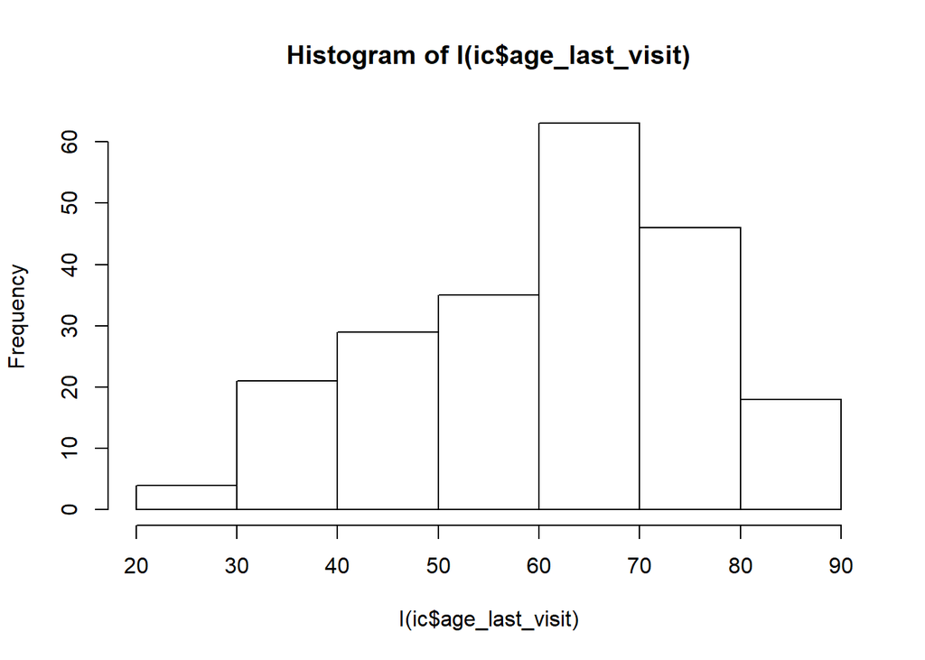

```r
hist(I(ic$age_last_visit))
```

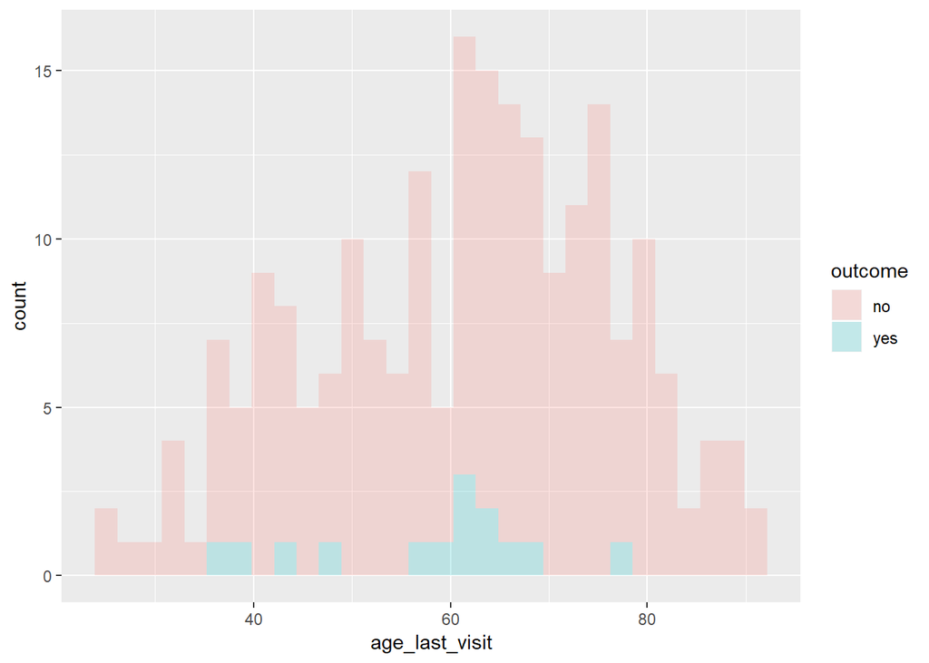

```r
ggplot(data=ic,aes(x=age_last_visit,group=outcome,fill=outcome)) + geom_histogram(alpha=0.2)
```

There is slight deviation from normality for Age in Last Visit for those who had Outcome = Yes. This is likely due to sample size issues.

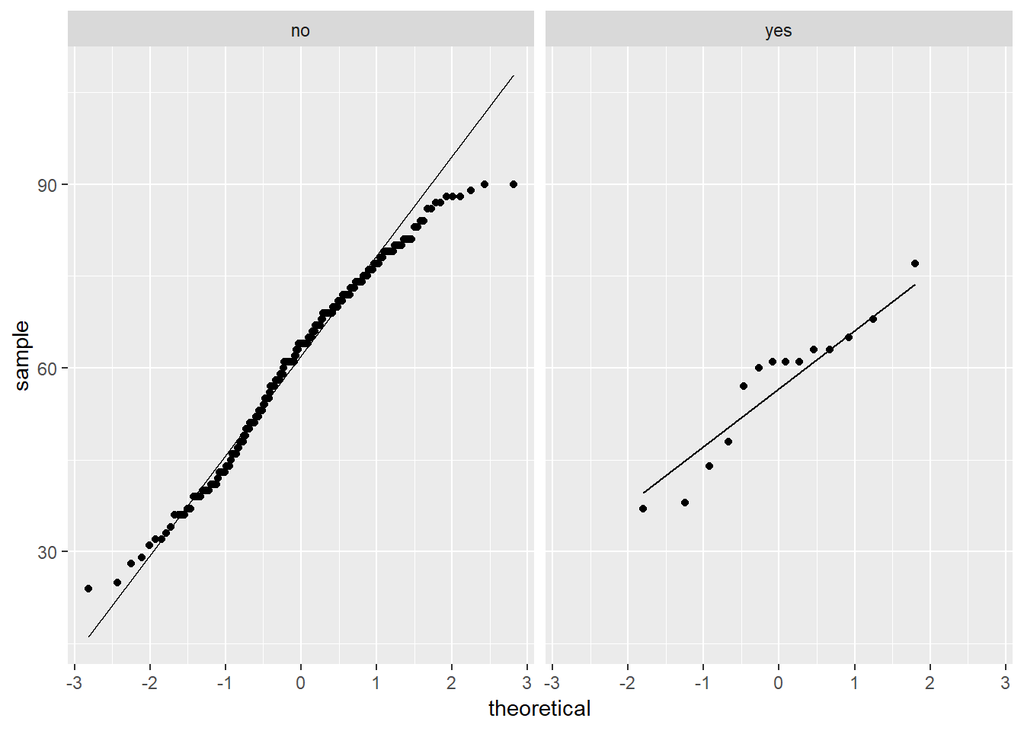

```r
ggplot(data=ic,aes(sample=age_last_visit)) + geom_qq() + geom_qq_line() + facet_grid(~outcome)
```

Levene’s test for Equality of variance does not reject the null hypothesis (Variances are equal)

```r
car::leveneTest(age_last_visit~outcome,data=ic)
```

```
## Levene's Test for Homogeneity of Variance (center = median)
##        Df F value  Pr(>F)
## group   1  3.0693 0.08122 .
##       214
## ---
## Signif. codes:  0 '***' 0.001 '**' 0.01 '*' 0.05 '.' 0.1 ' ' 1
```

We will use Independent Two-sample T-test (Pooled) We do not reject the null hypothesis that age at last visit is different across the outcome groups

```r
t.test(age_last_visit~outcome,data=ic,var.equal=TRUE)
```

```
##
##  Two Sample t-test
##
## data:  age_last_visit by outcome
## t = 1.008, df = 214, p-value = 0.3146
## alternative hypothesis: true difference in means is not equal to 0
## 95 percent confidence interval:
##  -3.991508 12.346529
## sample estimates:
##  mean in group no mean in group yes
##          61.53465          57.35714
```

Wilcoxon Rank Sum test confirms the above result.

```r
wilcox.test(age_last_visit~outcome,data=ic,var.equal=TRUE)
```

```
##
##  Wilcoxon rank sum test with continuity correction
##
## data:  age_last_visit by outcome
## W = 1704.5, p-value = 0.1995
## alternative hypothesis: true location shift is not equal to 0
```

##### We will use the results from Fisher’s exact tests

```r
chisq.test(ic$outcome,ic$race)
```

```
##
##  Pearson's Chi-squared test
##
## data:  ic$outcome and ic$race
## X-squared = 9.9212, df = 2, p-value = 0.007009
```

```r
chisq.test(ic$outcome,ic$race)$expected
```

```
##           ic$race
## ic$outcome    1 White   2 Black   3 Other
##        no  140.277778 43.953704 17.768519
##        yes   9.722222  3.046296  1.231481
```

```r
#Use Fisher's Exact since Yates' correction was applied
fisher.test(ic$outcome,ic$race)
```

```
##
##  Fisher's Exact Test for Count Data
##
## data:  ic$outcome and ic$race
## p-value = 0.009625
## alternative hypothesis: two.sided
```

NA values are ignored in chi-square. We will test missingness in univariate logistic

```r
chisq.test(ic$outcome,ic$smoking)
```

```
##
##  Pearson's Chi-squared test
##
## data:  ic$outcome and ic$smoking
## X-squared = 1.0669, df = 2, p-value = 0.5866
```

```r
chisq.test(ic$outcome,ic$smoking)$observed
```

```
##           ic$smoking
## ic$outcome 1 Never 2 Current 3 Former
##        no      143         5       45
##        yes      12         0        2
```

```r
chisq.test(ic$outcome,ic$smoking)$expected
```

```
##           ic$smoking
## ic$outcome   1 Never 2 Current  3 Former
##        no  144.51691 4.6618357 43.821256
##        yes  10.48309 0.3381643  3.178744
```

```r
#Use Fisher's Exact since Yates' correction was applied
fisher.test(ic$outcome,ic$smoking)
```

```
##
##  Fisher's Exact Test for Count Data
##
## data:  ic$outcome and ic$smoking
## p-value = 0.6687
## alternative hypothesis: two.sided
```

##### b. Pharmaceuticals

```r
chisq.test(ic$outcome,ic$elmiron)
```

```
##
##  Pearson's Chi-squared test with Yates' continuity correction
##
## data:  ic$outcome and ic$elmiron
## X-squared = 18.846, df = 1, p-value = 1.417e-05
```

```r
#Printing expected counts to check
chisq.test(ic$outcome,ic$elmiron)$expected
```

```
##           ic$elmiron
## ic$outcome         no       yes
##        no  118.768519 83.231481
##        yes   8.231481  5.768519
```

```r
#Use Fisher's Exact since Yates' correction was applied
fisher.test(ic$outcome,ic$elmiron)
```

```
##
##  Fisher's Exact Test for Count Data
##
## data:  ic$outcome and ic$elmiron
## p-value = 2.126e-06
## alternative hypothesis: true odds ratio is not equal to 1
## 95 percent confidence interval:
##  5.374642      Inf
## sample estimates:
## odds ratio
##        Inf
```

```r
chisq.test(ic$outcome,ic$hydroxyzine)
```

```
##
##  Pearson's Chi-squared test with Yates' continuity correction
##
## data:  ic$outcome and ic$hydroxyzine
## X-squared = 7.4503, df = 1, p-value = 0.006342
```

```r
#Printing expected counts to check
chisq.test(ic$outcome,ic$hydroxyzine)$expected
```

```
##           ic$hydroxyzine
## ic$outcome        no       yes
##        no  154.30556 47.694444
##        yes  10.69444  3.305556
```

```r
#Use Fisher's Exact since Yates' correction was applied
fisher.test(ic$outcome,ic$hydroxyzine)
```

```
##
##  Fisher's Exact Test for Count Data
##
## data:  ic$outcome and ic$hydroxyzine
## p-value = 0.005464
## alternative hypothesis: true odds ratio is not equal to 1
## 95 percent confidence interval:
##   1.401333 18.064288
## sample estimates:
## odds ratio
##   4.883051
```

```r
chisq.test(ic$outcome,ic$tca)
```

```
##
##  Pearson's Chi-squared test with Yates' continuity correction
##
## data:  ic$outcome and ic$tca
## X-squared = 0.14218, df = 1, p-value = 0.7061
```

```r
#Printing expected counts to check
chisq.test(ic$outcome,ic$tca)$expected
```

```
##           ic$tca
## ic$outcome        no       yes
##        no  145.88889 56.111111
##        yes  10.11111  3.888889
```

```r
#Use Fisher's Exact since Yates' correction was applied
fisher.test(ic$outcome,ic$tca)
```

```
##
##  Fisher's Exact Test for Count Data
##
## data:  ic$outcome and ic$tca
## p-value = 0.5403
## alternative hypothesis: true odds ratio is not equal to 1
## 95 percent confidence interval:
##  0.3732196 5.1848682
## sample estimates:
## odds ratio
##   1.481936
```

```r
chisq.test(ic$outcome,ic$gabapentin)
```

```
##
##  Pearson's Chi-squared test with Yates' continuity correction
##
## data:  ic$outcome and ic$gabapentin
## X-squared = 0.28667, df = 1, p-value = 0.5924
```

```r
#Printing expected counts to check
chisq.test(ic$outcome,ic$gabapentin)$expected
```

```
##           ic$gabapentin
## ic$outcome         no       yes
##        no  123.444444 78.555556
##        yes   8.555556  5.444444
```

```r
#Use Fisher's Exact since Yates' correction was applied
fisher.test(ic$outcome,ic$gabapentin)
```

```
##
##  Fisher's Exact Test for Count Data
##
## data:  ic$outcome and ic$gabapentin
## p-value = 0.5733
## alternative hypothesis: true odds ratio is not equal to 1
## 95 percent confidence interval:
##  0.1352313 2.2112229
## sample estimates:
## odds ratio
##  0.6113174
```

```r
chisq.test(ic$outcome,ic$hydroxychloroquine)
```

```
##
##  Pearson's Chi-squared test with Yates' continuity correction
##
## data:  ic$outcome and ic$hydroxychloroquine
## X-squared = 1.7054e-28, df = 1, p-value = 1
```

```r
#Printing expected counts to check
chisq.test(ic$outcome,ic$hydroxychloroquine)$expected
```

```
##           ic$hydroxychloroquine
## ic$outcome        no        yes
##        no  188.90741 13.0925926
##        yes  13.09259  0.9074074
```

```r
#Use Fisher's Exact since Yates' correction was applied
fisher.test(ic$outcome,ic$hydroxychloroquine)
```

```
##
##  Fisher's Exact Test for Count Data
##
## data:  ic$outcome and ic$hydroxychloroquine
## p-value = 1
## alternative hypothesis: true odds ratio is not equal to 1
## 95 percent confidence interval:
##  0.02445756 8.65451384
## sample estimates:
## odds ratio
##   1.117717
```

```r
chisq.test(ic$outcome,ic$cyclobenzaprine)
```

```
##
##  Pearson's Chi-squared test with Yates' continuity correction
##
## data:  ic$outcome and ic$cyclobenzaprine
## X-squared = 0.016011, df = 1, p-value = 0.8993
```

```r
#Printing expected counts to check
chisq.test(ic$outcome,ic$cyclobenzaprine)$expected
```

```
##           ic$cyclobenzaprine
## ic$outcome        no       yes
##        no  154.30556 47.694444
##        yes  10.69444  3.305556
```

```r
#Use Fisher's Exact since Yates' correction was applied
fisher.test(ic$outcome,ic$cyclobenzaprine)
```

```
##
##  Fisher's Exact Test for Count Data
##
## data:  ic$outcome and ic$cyclobenzaprine
## p-value = 0.7449
## alternative hypothesis: true odds ratio is not equal to 1
## 95 percent confidence interval:
##  0.2882253 4.8365741
## sample estimates:
## odds ratio
##   1.317352
```

```r
chisq.test(ic$outcome,ic$methenamine)
```

```
##
##  Pearson's Chi-squared test with Yates' continuity correction
##
## data:  ic$outcome and ic$methenamine
## X-squared = 1.9962e-29, df = 1, p-value = 1
```

```r
#Printing expected counts to check
chisq.test(ic$outcome,ic$methenamine)$expected
```

```
##           ic$methenamine
## ic$outcome        no       yes
##        no  162.72222 39.277778
##        yes  11.27778  2.722222
```

```r
#Use Fisher's Exact since Yates' correction was applied
fisher.test(ic$outcome,ic$methenamine)
```

```
##
##  Fisher's Exact Test for Count Data
##
## data:  ic$outcome and ic$methenamine
## p-value = 0.7383
## alternative hypothesis: true odds ratio is not equal to 1
## 95 percent confidence interval:
##  0.194873 4.598820
## sample estimates:
## odds ratio
##   1.139172
```

```r
chisq.test(ic$outcome,ic$phenazopyridine)
```

```
##
##  Pearson's Chi-squared test with Yates' continuity correction
##
## data:  ic$outcome and ic$phenazopyridine
## X-squared = 0.0066832, df = 1, p-value = 0.9348
```

```r
#Printing expected counts to check
chisq.test(ic$outcome,ic$phenazopyridine)$expected
```

```
##           ic$phenazopyridine
## ic$outcome        no      yes
##        no  149.62963 52.37037
##        yes  10.37037  3.62963
```

```r
#Use Fisher's Exact since Yates' correction was applied
fisher.test(ic$outcome,ic$phenazopyridine)
```

```
##
##  Fisher's Exact Test for Count Data
##
## data:  ic$outcome and ic$phenazopyridine
## p-value = 1
## alternative hypothesis: true odds ratio is not equal to 1
## 95 percent confidence interval:
##  0.1324983 3.0593697
## sample estimates:
## odds ratio
##  0.7676314
```

```r
chisq.test(ic$outcome,ic$oxybutynin)
```

```
##
##  Pearson's Chi-squared test with Yates' continuity correction
##
## data:  ic$outcome and ic$oxybutynin
## X-squared = 1.0241e-28, df = 1, p-value = 1
```

```r
#Printing expected counts to check
chisq.test(ic$outcome,ic$oxybutynin)$expected
```

```
##           ic$oxybutynin
## ic$outcome        no       yes
##        no  173.94444 28.055556
##        yes  12.05556  1.944444
```

```r
#Use Fisher's Exact since Yates' correction was applied
fisher.test(ic$outcome,ic$oxybutynin)
```

```
##
##  Fisher's Exact Test for Count Data
##
## data:  ic$outcome and ic$oxybutynin
## p-value = 1
## alternative hypothesis: true odds ratio is not equal to 1
## 95 percent confidence interval:
##  0.1070449 5.0421641
## sample estimates:
## odds ratio
##   1.035549
```

#### B. Univariate Logistic

##### a. Socio-demographics

```r
summary(glm(relevel(ic$outcome, ref = "no") ~ race,
            data=ic,family="binomial"))
```

```
##
## Call:
## glm(formula = relevel(ic$outcome, ref = "no") ~ race, family = "binomial",
##     data = ic)
##
## Deviance Residuals:
##      Min        1Q    Median        3Q       Max
## -0.68759  -0.37146  -0.37146  -0.00008   2.32725
##
## Coefficients:
##              Estimate Std. Error z value Pr(>|z|)
## (Intercept)   -2.6391     0.3273  -8.062 7.48e-16 ***
## race2 Black  -16.9270  1568.6340  -0.011    0.991
## race3 Other    1.3173     0.6510   2.023    0.043 *
## ---
## Signif. codes:  0 '***' 0.001 '**' 0.01 '*' 0.05 '.' 0.1 ' ' 1
##
## (Dispersion parameter for binomial family taken to be 1)
##
##     Null deviance: 103.687  on 215  degrees of freedom
## Residual deviance:  93.036  on 213  degrees of freedom
## AIC: 99.036
##
## Number of Fisher Scoring iterations: 18
```

```r
summary(glm(relevel(ic$outcome, ref = "no") ~ age_last_visit,
            data=ic,family="binomial"))
```

```
##
## Call:
## glm(formula = relevel(ic$outcome, ref = "no") ~ age_last_visit,
##     family = "binomial", data = ic)
##
## Deviance Residuals:
##     Min       1Q   Median       3Q      Max
## -0.4984  -0.3944  -0.3517  -0.3191   2.4649
##
## Coefficients:
##                Estimate Std. Error z value Pr(>|z|)
## (Intercept)    -1.58607    1.08140  -1.467    0.142
## age_last_visit -0.01821    0.01813  -1.005    0.315
##
## (Dispersion parameter for binomial family taken to be 1)
##
##     Null deviance: 103.69  on 215  degrees of freedom
## Residual deviance: 102.68  on 214  degrees of freedom
## AIC: 106.68
##
## Number of Fisher Scoring iterations: 5
```

```r
summary(glm(relevel(ic$outcome, ref = "no") ~ gender,
            data=ic,family="binomial"))
```

```
##
## Call:
## glm(formula = relevel(ic$outcome, ref = "no") ~ gender, family = "binomial",
##     data = ic)
##
## Deviance Residuals:
##     Min       1Q   Median       3Q      Max
## -0.3745  -0.3745  -0.3745  -0.3745   2.5211
##
## Coefficients:
##                Estimate Std. Error z value Pr(>|z|)
## (Intercept)     -2.6224     0.2872  -9.130   <2e-16 ***
## gender2 Female  -0.5131     1.0609  -0.484    0.629
## ---
## Signif. codes:  0 '***' 0.001 '**' 0.01 '*' 0.05 '.' 0.1 ' ' 1
##
## (Dispersion parameter for binomial family taken to be 1)
##
##     Null deviance: 103.69  on 215  degrees of freedom
## Residual deviance: 103.42  on 214  degrees of freedom
## AIC: 107.42
##
## Number of Fisher Scoring iterations: 5
```

```r
summary(glm(relevel(ic$outcome, ref = "no") ~ smoking,
            data=ic,family="binomial"))
```

```
##
## Call:
## glm(formula = relevel(ic$outcome, ref = "no") ~ smoking, family = "binomial",
##     data = ic)
##
## Deviance Residuals:
##     Min       1Q   Median       3Q      Max
## -0.4014  -0.4014  -0.4014  -0.2949   2.5128
##
## Coefficients:
##                   Estimate Std. Error z value Pr(>|z|)
## (Intercept)        -2.4779     0.3005  -8.245   <2e-16 ***
## smoking2 Current  -15.0881  1769.2577  -0.009    0.993
## smoking3 Former    -0.6356     0.7827  -0.812    0.417
## ---
## Signif. codes:  0 '***' 0.001 '**' 0.01 '*' 0.05 '.' 0.1 ' ' 1
##
## (Dispersion parameter for binomial family taken to be 1)
##
##     Null deviance: 102.45  on 206  degrees of freedom
## Residual deviance: 100.99  on 204  degrees of freedom
##   (9 observations deleted due to missingness)
## AIC: 106.99
##
## Number of Fisher Scoring iterations: 16
```

##### b. Pharmaceuticals

Though the elmiron coeffcient is not significant it is HIGH! The AIC of the model (measure of goodness of fit is also lowest- which is good) is lower than other models we have fit (best approximating model to the unknown data generating process).

```r
summary(glm(relevel(ic$outcome, ref = "no") ~ elmiron,
            data=ic,family="binomial"))
```

```
##
## Call:
## glm(formula = relevel(ic$outcome, ref = "no") ~ elmiron, family = "binomial",
##     data = ic)
##
## Deviance Residuals:
##      Min        1Q    Median        3Q       Max
## -0.58506  -0.58506  -0.00005  -0.00005   1.92332
##
## Coefficients:
##             Estimate Std. Error z value Pr(>|z|)
## (Intercept)   -20.57    1573.32  -0.013     0.99
## elmironyes     18.89    1573.32   0.012     0.99
##
## (Dispersion parameter for binomial family taken to be 1)
##
##     Null deviance: 103.69  on 215  degrees of freedom
## Residual deviance:  77.46  on 214  degrees of freedom
## AIC: 81.46
##
## Number of Fisher Scoring iterations: 19
```

```r
summary(glm(relevel(ic$outcome, ref = "no") ~ hydroxyzine,
            data=ic,family="binomial"))
```

```
##
## Call:
## glm(formula = relevel(ic$outcome, ref = "no") ~ hydroxyzine,
##     family = "binomial", data = ic)
##
## Deviance Residuals:
##     Min       1Q   Median       3Q      Max
## -0.5842  -0.2722  -0.2722  -0.2722   2.5746
##
## Coefficients:
##                Estimate Std. Error z value Pr(>|z|)
## (Intercept)     -3.2771     0.4159  -7.880 3.27e-15 ***
## hydroxyzineyes   1.5954     0.5668   2.815  0.00488 **
## ---
## Signif. codes:  0 '***' 0.001 '**' 0.01 '*' 0.05 '.' 0.1 ' ' 1
##
## (Dispersion parameter for binomial family taken to be 1)
##
##     Null deviance: 103.687  on 215  degrees of freedom
## Residual deviance:  95.861  on 214  degrees of freedom
## AIC: 99.861
##
## Number of Fisher Scoring iterations: 6
```

```r
summary(glm(relevel(ic$outcome, ref = "no") ~ tca,
            data=ic,family="binomial"))
```

```
##
## Call:
## glm(formula = relevel(ic$outcome, ref = "no") ~ tca, family = "binomial",
##     data = ic)
##
## Deviance Residuals:
##     Min       1Q   Median       3Q      Max
## -0.4172  -0.4172  -0.3447  -0.3447   2.3886
##
## Coefficients:
##             Estimate Std. Error z value Pr(>|z|)
## (Intercept)  -2.7932     0.3434  -8.134 4.14e-16 ***
## tcayes        0.3953     0.5797   0.682    0.495
## ---
## Signif. codes:  0 '***' 0.001 '**' 0.01 '*' 0.05 '.' 0.1 ' ' 1
##
## (Dispersion parameter for binomial family taken to be 1)
##
##     Null deviance: 103.69  on 215  degrees of freedom
## Residual deviance: 103.24  on 214  degrees of freedom
## AIC: 107.24
##
## Number of Fisher Scoring iterations: 5
```

```r
summary(glm(relevel(ic$outcome, ref = "no") ~ gabapentin,
            data=ic,family="binomial"))
```

```
##
## Call:
## glm(formula = relevel(ic$outcome, ref = "no") ~ gabapentin, family = "binomial",
##     data = ic)
##
## Deviance Residuals:
##     Min       1Q   Median       3Q      Max
## -0.3969  -0.3969  -0.3969  -0.3124   2.4676
##
## Coefficients:
##               Estimate Std. Error z value Pr(>|z|)
## (Intercept)    -2.5014     0.3289  -7.605 2.86e-14 ***
## gabapentinyes  -0.4943     0.6088  -0.812    0.417
## ---
## Signif. codes:  0 '***' 0.001 '**' 0.01 '*' 0.05 '.' 0.1 ' ' 1
##
## (Dispersion parameter for binomial family taken to be 1)
##
##     Null deviance: 103.69  on 215  degrees of freedom
## Residual deviance: 102.99  on 214  degrees of freedom
## AIC: 106.99
##
## Number of Fisher Scoring iterations: 5
```

```r
summary(glm(relevel(ic$outcome, ref = "no") ~ hydroxychloroquine,
            data=ic,family="binomial"))
```

```
##
## Call:
## glm(formula = relevel(ic$outcome, ref = "no") ~ hydroxychloroquine,
##     family = "binomial", data = ic)
##
## Deviance Residuals:
##     Min       1Q   Median       3Q      Max
## -0.3850  -0.3648  -0.3648  -0.3648   2.3424
##
## Coefficients:
##                       Estimate Std. Error z value Pr(>|z|)
## (Intercept)            -2.6768     0.2867  -9.336   <2e-16 ***
## hydroxychloroquineyes   0.1118     1.0766   0.104    0.917
## ---
## Signif. codes:  0 '***' 0.001 '**' 0.01 '*' 0.05 '.' 0.1 ' ' 1
##
## (Dispersion parameter for binomial family taken to be 1)
##
##     Null deviance: 103.69  on 215  degrees of freedom
## Residual deviance: 103.68  on 214  degrees of freedom
## AIC: 107.68
##
## Number of Fisher Scoring iterations: 5
```

```r
summary(glm(relevel(ic$outcome, ref = "no") ~ cyclobenzaprine,
            data=ic,family="binomial"))
```

```
##
## Call:
## glm(formula = relevel(ic$outcome, ref = "no") ~ cyclobenzaprine,
##     family = "binomial", data = ic)
##
## Deviance Residuals:
##     Min       1Q   Median       3Q      Max
## -0.4042  -0.3536  -0.3536  -0.3536   2.3678
##
## Coefficients:
##                    Estimate Std. Error z value Pr(>|z|)
## (Intercept)         -2.7408     0.3263  -8.401   <2e-16 ***
## cyclobenzaprineyes   0.2770     0.6146   0.451    0.652
## ---
## Signif. codes:  0 '***' 0.001 '**' 0.01 '*' 0.05 '.' 0.1 ' ' 1
##
## (Dispersion parameter for binomial family taken to be 1)
##
##     Null deviance: 103.69  on 215  degrees of freedom
## Residual deviance: 103.49  on 214  degrees of freedom
## AIC: 107.49
##
## Number of Fisher Scoring iterations: 5
```

```r
summary(glm(relevel(ic$outcome, ref = "no") ~ methenamine,
            data=ic,family="binomial"))
```

```
##
## Call:
## glm(formula = relevel(ic$outcome, ref = "no") ~ methenamine,
##     family = "binomial", data = ic)
##
## Deviance Residuals:
##     Min       1Q   Median       3Q      Max
## -0.3850  -0.3614  -0.3614  -0.3614   2.3500
##
## Coefficients:
##                Estimate Std. Error z value Pr(>|z|)
## (Intercept)     -2.6959     0.3115  -8.654   <2e-16 ***
## methenamineyes   0.1309     0.6753   0.194    0.846
## ---
## Signif. codes:  0 '***' 0.001 '**' 0.01 '*' 0.05 '.' 0.1 ' ' 1
##
## (Dispersion parameter for binomial family taken to be 1)
##
##     Null deviance: 103.69  on 215  degrees of freedom
## Residual deviance: 103.65  on 214  degrees of freedom
## AIC: 107.65
##
## Number of Fisher Scoring iterations: 5
```

```r
summary(glm(relevel(ic$outcome, ref = "no") ~ phenazopyridine,
            data=ic,family="binomial"))
```

```
##
## Call:
## glm(formula = relevel(ic$outcome, ref = "no") ~ phenazopyridine,
##     family = "binomial", data = ic)
##
## Deviance Residuals:
##     Min       1Q   Median       3Q      Max
## -0.3774  -0.3774  -0.3774  -0.3318   2.4194
##
## Coefficients:
##                    Estimate Std. Error z value Pr(>|z|)
## (Intercept)         -2.6061     0.3124  -8.341   <2e-16 ***
## phenazopyridineyes  -0.2656     0.6707  -0.396    0.692
## ---
## Signif. codes:  0 '***' 0.001 '**' 0.01 '*' 0.05 '.' 0.1 ' ' 1
##
## (Dispersion parameter for binomial family taken to be 1)
##
##     Null deviance: 103.69  on 215  degrees of freedom
## Residual deviance: 103.52  on 214  degrees of freedom
## AIC: 107.52
##
## Number of Fisher Scoring iterations: 5
```

```r
summary(glm(relevel(ic$outcome, ref = "no") ~ oxybutynin,
            data=ic,family="binomial"))
```

```
##
## Call:
## glm(formula = relevel(ic$outcome, ref = "no") ~ oxybutynin, family = "binomial",
##     data = ic)
##
## Deviance Residuals:
##     Min       1Q   Median       3Q      Max
## -0.3715  -0.3652  -0.3652  -0.3652   2.3413
##
## Coefficients:
##               Estimate Std. Error z value Pr(>|z|)
## (Intercept)   -2.67415    0.29846  -8.960   <2e-16 ***
## oxybutyninyes  0.03509    0.79044   0.044    0.965
## ---
## Signif. codes:  0 '***' 0.001 '**' 0.01 '*' 0.05 '.' 0.1 ' ' 1
##
## (Dispersion parameter for binomial family taken to be 1)
##
##     Null deviance: 103.69  on 215  degrees of freedom
## Residual deviance: 103.68  on 214  degrees of freedom
## AIC: 107.68
##
## Number of Fisher Scoring iterations: 5
```

#### C. Multiple Logistic

Adjusting for age, gender, race and smoking status The AIC for this model is higher than for the parsimonious model. Explanation: This model with more variables is penalized for its fit which is probably similar to the model with Elmiron alone.

```r
summary(glm(relevel(ic$outcome, ref = "no") ~ race + age_last_visit + gender + smoking + elmiron,
            data=ic,family="binomial"))
```

```
##
## Call:
## glm(formula = relevel(ic$outcome, ref = "no") ~ race + age_last_visit +
##     gender + smoking + elmiron, family = "binomial", data = ic)
##
## Deviance Residuals:
##      Min        1Q    Median        3Q       Max
## -0.92295  -0.45339  -0.00004  -0.00003   2.11348
##
## Coefficients:
##                    Estimate Std. Error z value Pr(>|z|)
## (Intercept)      -2.061e+01  2.537e+03  -0.008    0.994
## race2 Black      -1.855e+01  3.710e+03  -0.005    0.996
## race3 Other       7.027e-01  6.987e-01   1.006    0.315
## age_last_visit   -9.836e-03  2.126e-02  -0.463    0.644
## gender2 Female    3.313e-01  1.234e+00   0.268    0.788
## smoking2 Current -1.792e+01  1.058e+04  -0.002    0.999
## smoking3 Former  -6.368e-01  8.754e-01  -0.727    0.467
## elmironyes        1.973e+01  2.537e+03   0.008    0.994
##
## (Dispersion parameter for binomial family taken to be 1)
##
##     Null deviance: 102.454  on 206  degrees of freedom
## Residual deviance:  68.498  on 199  degrees of freedom
##   (9 observations deleted due to missingness)
## AIC: 84.498
##
## Number of Fisher Scoring iterations: 20
```

### 4. 1 vs 3,4

#### A. Hypothesis Tests

```r
ic <- ic[ic$cases %in% c("1 Definite","3 Not", "4 No images"),]
ic$outcome <- with(ic, as.factor(ifelse(cases %in% c("1 Definite"),"yes","no")))

table(ic$outcome,useNA="always")
```

```
##
##   no  yes <NA>
##  191   14    0
```

##### a. Socio-demographics

```r
chisq.test(ic$outcome,ic$gender)
```

```
##
##  Pearson's Chi-squared test with Yates' continuity correction
##
## data:  ic$outcome and ic$gender
## X-squared = 4.7606e-06, df = 1, p-value = 0.9983
```

```r
chisq.test(ic$outcome,ic$gender)$expected
```

```
##           ic$gender
## ic$outcome    1 Male  2 Female
##        no  170.50244 20.497561
##        yes  12.49756  1.502439
```

```r
fisher.test(ic$outcome,ic$gender)
```

```
##
##  Fisher's Exact Test for Count Data
##
## data:  ic$outcome and ic$gender
## p-value = 1
## alternative hypothesis: true odds ratio is not equal to 1
## 95 percent confidence interval:
##  0.01399853 4.57442539
## sample estimates:
## odds ratio
##  0.6239352
```

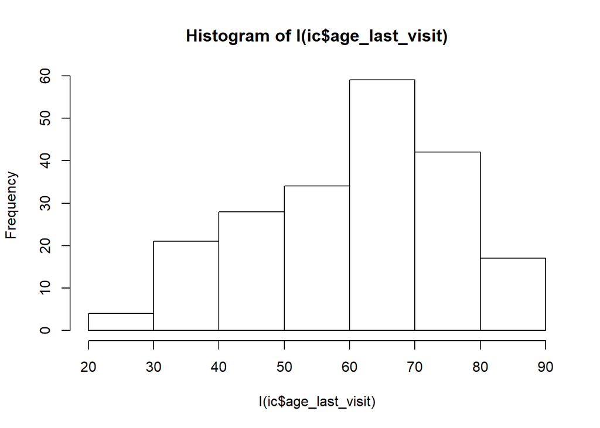

```r
hist(I(ic$age_last_visit))
```

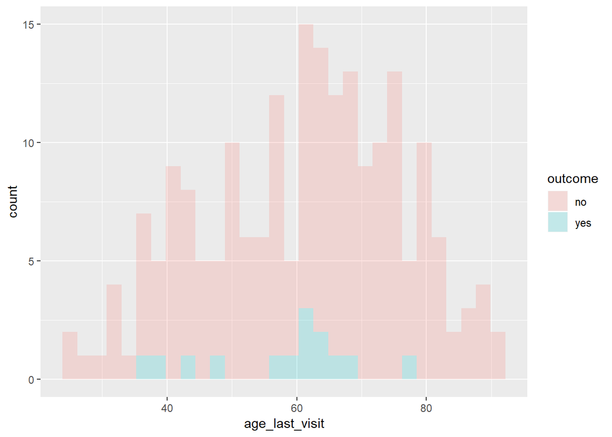

```r
ggplot(data=ic,aes(x=age_last_visit,group=outcome,fill=outcome)) + geom_histogram(alpha=0.2)
```

There is slight deviation from normality for Age in Last Visit for those who had Outcome = Yes. This is likely due to sample size issues.

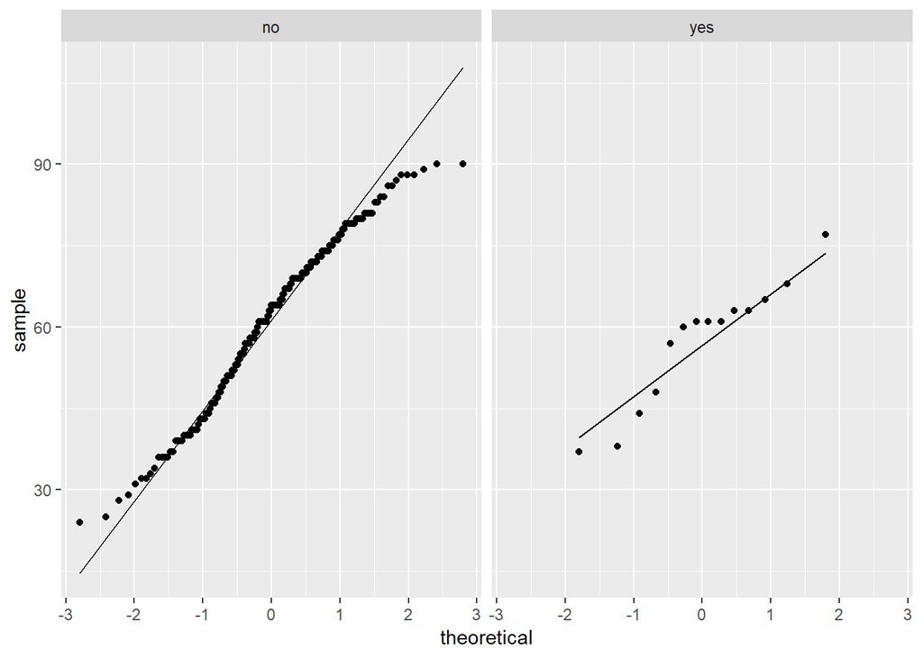

```r
ggplot(data=ic,aes(sample=age_last_visit)) + geom_qq() + geom_qq_line() + facet_grid(~outcome)
```

Levene’s test for Equality of variance does not reject the null hypothesis (Variances are equal)

```r
car::leveneTest(age_last_visit~outcome,data=ic)
```

```
## Levene's Test for Homogeneity of Variance (center = median)
##        Df F value Pr(>F)
## group   1  3.2755 0.0718 .
##       203
## ---
## Signif. codes:  0 '***' 0.001 '**' 0.01 '*' 0.05 '.' 0.1 ' ' 1
```

We will use Independent Two-sample T-test (Pooled) We do not reject the null hypothesis that age at last visit is different across the outcome groups

```r
t.test(age_last_visit~outcome,data=ic,var.equal=TRUE)
```

```
##
##  Two Sample t-test
##
## data:  age_last_visit by outcome
## t = 0.91288, df = 203, p-value = 0.3624
## alternative hypothesis: true difference in means is not equal to 0
## 95 percent confidence interval:
##  -4.431757 12.073492
## sample estimates:
##  mean in group no mean in group yes
##          61.17801          57.35714
```

Wilcoxon Rank Sum test confirms the above result.

```r
wilcox.test(age_last_visit~outcome,data=ic,var.equal=TRUE)
```

```
##
##  Wilcoxon rank sum test with continuity correction
##
## data:  age_last_visit by outcome
## W = 1588, p-value = 0.2421
## alternative hypothesis: true location shift is not equal to 0
```

##### We will use the results from Fisher’s exact tests

```r
chisq.test(ic$outcome,ic$race)
```

```
##
##  Pearson's Chi-squared test
##
## data:  ic$outcome and ic$race
## X-squared = 10.011, df = 2, p-value = 0.006699
```

```r
chisq.test(ic$outcome,ic$race)$expected
```

```
##           ic$race
## ic$outcome    1 White   2 Black   3 Other
##        no  132.302439 41.926829 16.770732
##        yes   9.697561  3.073171  1.229268
```

```r
#Use Fisher's Exact since Yates' correction was applied
fisher.test(ic$outcome,ic$race)
```

```
##
##  Fisher's Exact Test for Count Data
##
## data:  ic$outcome and ic$race
## p-value = 0.008318
## alternative hypothesis: two.sided
```

NA values are ignored in chi-square. We will test missingness in univariate logistic

```r
chisq.test(ic$outcome,ic$smoking)
```

```
##
##  Pearson's Chi-squared test
##
## data:  ic$outcome and ic$smoking
## X-squared = 1.0629, df = 2, p-value = 0.5877
```

```r
chisq.test(ic$outcome,ic$smoking)$observed
```

```
##           ic$smoking
## ic$outcome 1 Never 2 Current 3 Former
##        no      135         5       42
##        yes      12         0        2
```

```r
chisq.test(ic$outcome,ic$smoking)$expected
```

```
##           ic$smoking
## ic$outcome 1 Never 2 Current  3 Former
##        no    136.5 4.6428571 40.857143
##        yes    10.5 0.3571429  3.142857
```

```r
#Use Fisher's Exact since Yates' correction was applied
fisher.test(ic$outcome,ic$smoking)
```

```
##
##  Fisher's Exact Test for Count Data
##
## data:  ic$outcome and ic$smoking
## p-value = 0.6757
## alternative hypothesis: two.sided
```

##### b. Pharmaceuticals

```r
chisq.test(ic$outcome,ic$elmiron)
```

```
##
##  Pearson's Chi-squared test with Yates' continuity correction
##
## data:  ic$outcome and ic$elmiron
## X-squared = 19.936, df = 1, p-value = 8.008e-06
```

```r
#Printing expected counts to check
chisq.test(ic$outcome,ic$elmiron)$expected
```

```
##           ic$elmiron
## ic$outcome    no  yes
##        no  114.6 76.4
##        yes   8.4  5.6
```

```r
#Use Fisher's Exact since Yates' correction was applied
fisher.test(ic$outcome,ic$elmiron)
```

```
##
##  Fisher's Exact Test for Count Data
##
## data:  ic$outcome and ic$elmiron
## p-value = 1.304e-06
## alternative hypothesis: true odds ratio is not equal to 1
## 95 percent confidence interval:
##  5.720423      Inf
## sample estimates:
## odds ratio
##        Inf
```

```r
chisq.test(ic$outcome,ic$hydroxyzine)
```

```
##
##  Pearson's Chi-squared test with Yates' continuity correction
##
## data:  ic$outcome and ic$hydroxyzine
## X-squared = 6.9384, df = 1, p-value = 0.008436
```

```r
#Printing expected counts to check
chisq.test(ic$outcome,ic$hydroxyzine)$expected
```

```
##           ic$hydroxyzine
## ic$outcome        no       yes
##        no  144.41463 46.585366
##        yes  10.58537  3.414634
```

```r
#Use Fisher's Exact since Yates' correction was applied
fisher.test(ic$outcome,ic$hydroxyzine)
```

```
##
##  Fisher's Exact Test for Count Data
##
## data:  ic$outcome and ic$hydroxyzine
## p-value = 0.006752
## alternative hypothesis: true odds ratio is not equal to 1
## 95 percent confidence interval:
##   1.34176 17.36274
## sample estimates:
## odds ratio
##   4.684453
```

```r
chisq.test(ic$outcome,ic$tca)
```

```
##
##  Pearson's Chi-squared test with Yates' continuity correction
##
## data:  ic$outcome and ic$tca
## X-squared = 0.10979, df = 1, p-value = 0.7404
```

```r
#Printing expected counts to check
chisq.test(ic$outcome,ic$tca)$expected
```

```
##           ic$tca
## ic$outcome        no       yes
##        no  136.96098 54.039024
##        yes  10.03902  3.960976
```

```r
#Use Fisher's Exact since Yates' correction was applied
fisher.test(ic$outcome,ic$tca)
```

```
##
##  Fisher's Exact Test for Count Data
##
## data:  ic$outcome and ic$tca
## p-value = 0.5448
## alternative hypothesis: true odds ratio is not equal to 1
## 95 percent confidence interval:
##  0.3628799 5.0630340
## sample estimates:
## odds ratio
##   1.443767
```

```r
chisq.test(ic$outcome,ic$gabapentin)
```

```
##
##  Pearson's Chi-squared test with Yates' continuity correction
##
## data:  ic$outcome and ic$gabapentin
## X-squared = 0.34143, df = 1, p-value = 0.559
```

```r
#Printing expected counts to check
chisq.test(ic$outcome,ic$gabapentin)$expected
```

```
##           ic$gabapentin
## ic$outcome         no       yes
##        no  115.531707 75.468293
##        yes   8.468293  5.531707
```

```r
#Use Fisher's Exact since Yates' correction was applied
fisher.test(ic$outcome,ic$gabapentin)
```

```
##
##  Fisher's Exact Test for Count Data
##
## data:  ic$outcome and ic$gabapentin
## p-value = 0.5726
## alternative hypothesis: true odds ratio is not equal to 1
## 95 percent confidence interval:
##  0.1311015 2.1518461
## sample estimates:
## odds ratio
##  0.5936355
```

```r
chisq.test(ic$outcome,ic$hydroxychloroquine)
```

```
##
##  Pearson's Chi-squared test with Yates' continuity correction
##
## data:  ic$outcome and ic$hydroxychloroquine
## X-squared = 1.5446e-30, df = 1, p-value = 1
```

```r
#Printing expected counts to check
chisq.test(ic$outcome,ic$hydroxychloroquine)$expected
```

```
##           ic$hydroxychloroquine
## ic$outcome       no        yes
##        no  178.8878 12.1121951
##        yes  13.1122  0.8878049
```

```r
#Use Fisher's Exact since Yates' correction was applied
fisher.test(ic$outcome,ic$hydroxychloroquine)
```

```
##
##  Fisher's Exact Test for Count Data
##
## data:  ic$outcome and ic$hydroxychloroquine
## p-value = 1
## alternative hypothesis: true odds ratio is not equal to 1
## 95 percent confidence interval:
##  0.024947 8.992856
## sample estimates:
## odds ratio
##   1.146616
```

```r
chisq.test(ic$outcome,ic$cyclobenzaprine)
```

```
##
##  Pearson's Chi-squared test with Yates' continuity correction
##
## data:  ic$outcome and ic$cyclobenzaprine
## X-squared = 0.036549, df = 1, p-value = 0.8484
```

```r
#Printing expected counts to check
chisq.test(ic$outcome,ic$cyclobenzaprine)$expected
```

```
##           ic$cyclobenzaprine
## ic$outcome        no       yes
##        no  147.20976 43.790244
##        yes  10.79024  3.209756
```

```r
#Use Fisher's Exact since Yates' correction was applied
fisher.test(ic$outcome,ic$cyclobenzaprine)
```

```
##
##  Fisher's Exact Test for Count Data
##
## data:  ic$outcome and ic$cyclobenzaprine
## p-value = 0.7416
## alternative hypothesis: true odds ratio is not equal to 1
## 95 percent confidence interval:
##  0.2996099 5.0696262
## sample estimates:
## odds ratio
##   1.374439
```

```r
chisq.test(ic$outcome,ic$methenamine)
```

```
##
##  Pearson's Chi-squared test with Yates' continuity correction
##
## data:  ic$outcome and ic$methenamine
## X-squared = 3.3985e-30, df = 1, p-value = 1
```

```r
#Printing expected counts to check
chisq.test(ic$outcome,ic$methenamine)$expected
```

```
##           ic$methenamine
## ic$outcome        no       yes
##        no  153.73171 37.268293
##        yes  11.26829  2.731707
```

```r
#Use Fisher's Exact since Yates' correction was applied
fisher.test(ic$outcome,ic$methenamine)
```

```
##
##  Fisher's Exact Test for Count Data
##
## data:  ic$outcome and ic$methenamine
## p-value = 0.739
## alternative hypothesis: true odds ratio is not equal to 1
## 95 percent confidence interval:
##  0.193584 4.595980
## sample estimates:
## odds ratio
##   1.134435
```

```r
chisq.test(ic$outcome,ic$phenazopyridine)
```

```
##
##  Pearson's Chi-squared test with Yates' continuity correction
##
## data:  ic$outcome and ic$phenazopyridine
## X-squared = 0.013936, df = 1, p-value = 0.906
```

```r
#Printing expected counts to check
chisq.test(ic$outcome,ic$phenazopyridine)$expected
```

```
##           ic$phenazopyridine
## ic$outcome       no       yes
##        no  140.6878 50.312195
##        yes  10.3122  3.687805
```

```r
#Use Fisher's Exact since Yates' correction was applied
fisher.test(ic$outcome,ic$phenazopyridine)
```

```
##
##  Fisher's Exact Test for Count Data
##
## data:  ic$outcome and ic$phenazopyridine
## p-value = 1
## alternative hypothesis: true odds ratio is not equal to 1
## 95 percent confidence interval:
##  0.1291774 2.9947424
## sample estimates:
## odds ratio
##  0.7496807
```

```r
chisq.test(ic$outcome,ic$oxybutynin)
```

```
##
##  Pearson's Chi-squared test with Yates' continuity correction
##
## data:  ic$outcome and ic$oxybutynin
## X-squared = 2.2174e-30, df = 1, p-value = 1
```

```r
#Printing expected counts to check
chisq.test(ic$outcome,ic$oxybutynin)$expected
```

```
##           ic$oxybutynin
## ic$outcome       no       yes
##        no  164.9122 26.087805
##        yes  12.0878  1.912195
```

```r
#Use Fisher's Exact since Yates' correction was applied
fisher.test(ic$outcome,ic$oxybutynin)
```

```
##
##  Fisher's Exact Test for Count Data
##
## data:  ic$outcome and ic$oxybutynin
## p-value = 1
## alternative hypothesis: true odds ratio is not equal to 1
## 95 percent confidence interval:
##  0.1089089 5.1796951
## sample estimates:
## odds ratio
##   1.057409
```

#### B. Univariate Logistic

##### a. Socio-demographics

```r
summary(glm(relevel(ic$outcome, ref = "no") ~ race,
            data=ic,family="binomial"))
```

```
##
## Call:
## glm(formula = relevel(ic$outcome, ref = "no") ~ race, family = "binomial",
##     data = ic)
##
## Deviance Residuals:
##      Min        1Q    Median        3Q       Max
## -0.70896  -0.38217  -0.38217  -0.00008   2.30358
##
## Coefficients:
##             Estimate Std. Error z value Pr(>|z|)
## (Intercept)   -2.580      0.328  -7.867 3.64e-15 ***
## race2 Black  -16.986   1603.114  -0.011   0.9915
## race3 Other    1.327      0.655   2.027   0.0427 *
## ---
## Signif. codes:  0 '***' 0.001 '**' 0.01 '*' 0.05 '.' 0.1 ' ' 1
##
## (Dispersion parameter for binomial family taken to be 1)
##
##     Null deviance: 102.172  on 204  degrees of freedom
## Residual deviance:  91.413  on 202  degrees of freedom
## AIC: 97.413
##
## Number of Fisher Scoring iterations: 18
```

```r
summary(glm(relevel(ic$outcome, ref = "no") ~ age_last_visit,
            data=ic,family="binomial"))
```

```
##
## Call:
## glm(formula = relevel(ic$outcome, ref = "no") ~ age_last_visit,
##     family = "binomial", data = ic)
##
## Deviance Residuals:
##     Min       1Q   Median       3Q      Max
## -0.4964  -0.4017  -0.3623  -0.3317   2.4325
##
## Coefficients:
##                Estimate Std. Error z value Pr(>|z|)
## (Intercept)    -1.63615    1.07885  -1.517    0.129
## age_last_visit -0.01648    0.01809  -0.911    0.362
##
## (Dispersion parameter for binomial family taken to be 1)
##
##     Null deviance: 102.17  on 204  degrees of freedom
## Residual deviance: 101.35  on 203  degrees of freedom
## AIC: 105.35
##
## Number of Fisher Scoring iterations: 5
```

```r
summary(glm(relevel(ic$outcome, ref = "no") ~ gender,
            data=ic,family="binomial"))
```

```
##
## Call:
## glm(formula = relevel(ic$outcome, ref = "no") ~ gender, family = "binomial",
##     data = ic)
##
## Deviance Residuals:
##     Min       1Q   Median       3Q      Max
## -0.3839  -0.3839  -0.3839  -0.3839   2.4864
##
## Coefficients:
##                Estimate Std. Error z value Pr(>|z|)
## (Intercept)     -2.5708     0.2878  -8.934   <2e-16 ***
## gender2 Female  -0.4737     1.0631  -0.446    0.656
## ---
## Signif. codes:  0 '***' 0.001 '**' 0.01 '*' 0.05 '.' 0.1 ' ' 1
##
## (Dispersion parameter for binomial family taken to be 1)
##
##     Null deviance: 102.17  on 204  degrees of freedom
## Residual deviance: 101.95  on 203  degrees of freedom
## AIC: 105.95
##
## Number of Fisher Scoring iterations: 5
```

```r
summary(glm(relevel(ic$outcome, ref = "no") ~ smoking,
            data=ic,family="binomial"))
```

```
##
## Call:
## glm(formula = relevel(ic$outcome, ref = "no") ~ smoking, family = "binomial",
##     data = ic)
##
## Deviance Residuals:
##     Min       1Q   Median       3Q      Max
## -0.4127  -0.4127  -0.4127  -0.3050   2.4864
##
## Coefficients:
##                   Estimate Std. Error z value Pr(>|z|)
## (Intercept)        -2.4204     0.3012  -8.035 9.37e-16 ***
## smoking2 Current  -15.1457  1769.2577  -0.009    0.993
## smoking3 Former    -0.6242     0.7839  -0.796    0.426
## ---
## Signif. codes:  0 '***' 0.001 '**' 0.01 '*' 0.05 '.' 0.1 ' ' 1
##
## (Dispersion parameter for binomial family taken to be 1)
##
##     Null deviance: 100.869  on 195  degrees of freedom
## Residual deviance:  99.397  on 193  degrees of freedom
##   (9 observations deleted due to missingness)
## AIC: 105.4
##
## Number of Fisher Scoring iterations: 16
```

##### b. Pharmaceuticals

Though the elmiron coeffcient is not significant it is HIGH! The AIC of the model (measure of goodness of fit is also lowest- which is good) is lower than other models we have fit (best approximating model to the unknown data generating process).

```r
summary(glm(relevel(ic$outcome, ref = "no") ~ elmiron,
            data=ic,family="binomial"))
```

```
##
## Call:
## glm(formula = relevel(ic$outcome, ref = "no") ~ elmiron, family = "binomial",
##     data = ic)
##
## Deviance Residuals:
##      Min        1Q    Median        3Q       Max
## -0.61190  -0.61190  -0.00005  -0.00005   1.88025
##
## Coefficients:
##             Estimate Std. Error z value Pr(>|z|)
## (Intercept)   -20.57    1598.69  -0.013    0.990
## elmironyes     18.99    1598.69   0.012    0.991
##
## (Dispersion parameter for binomial family taken to be 1)
##
##     Null deviance: 102.172  on 204  degrees of freedom
## Residual deviance:  74.955  on 203  degrees of freedom
## AIC: 78.955
##
## Number of Fisher Scoring iterations: 19
```

```r
summary(glm(relevel(ic$outcome, ref = "no") ~ hydroxyzine,
            data=ic,family="binomial"))
```

```
##
## Call:
## glm(formula = relevel(ic$outcome, ref = "no") ~ hydroxyzine,
##     family = "binomial", data = ic)
##
## Deviance Residuals:
##     Min       1Q   Median       3Q      Max
## -0.5905  -0.2810  -0.2810  -0.2810   2.5502
##
## Coefficients:
##                Estimate Std. Error z value Pr(>|z|)
## (Intercept)     -3.2122     0.4164  -7.714 1.22e-14 ***
## hydroxyzineyes   1.5540     0.5676   2.738  0.00619 **
## ---
## Signif. codes:  0 '***' 0.001 '**' 0.01 '*' 0.05 '.' 0.1 ' ' 1
##
## (Dispersion parameter for binomial family taken to be 1)
##
##     Null deviance: 102.172  on 204  degrees of freedom
## Residual deviance:  94.752  on 203  degrees of freedom
## AIC: 98.752
##
## Number of Fisher Scoring iterations: 6
```

```r
summary(glm(relevel(ic$outcome, ref = "no") ~ tca,
            data=ic,family="binomial"))
```

```
##
## Call:
## glm(formula = relevel(ic$outcome, ref = "no") ~ tca, family = "binomial",
##     data = ic)
##
## Deviance Residuals:
##     Min       1Q   Median       3Q      Max
## -0.4246  -0.4246  -0.3555  -0.3555   2.3636
##
## Coefficients:
##             Estimate Std. Error z value Pr(>|z|)
## (Intercept)  -2.7300     0.3440  -7.935  2.1e-15 ***
## tcayes        0.3692     0.5807   0.636    0.525
## ---
## Signif. codes:  0 '***' 0.001 '**' 0.01 '*' 0.05 '.' 0.1 ' ' 1
##
## (Dispersion parameter for binomial family taken to be 1)
##
##     Null deviance: 102.17  on 204  degrees of freedom
## Residual deviance: 101.78  on 203  degrees of freedom
## AIC: 105.78
##
## Number of Fisher Scoring iterations: 5
```

```r
summary(glm(relevel(ic$outcome, ref = "no") ~ gabapentin,
            data=ic,family="binomial"))
```

```
##
## Call:
## glm(formula = relevel(ic$outcome, ref = "no") ~ gabapentin, family = "binomial",
##     data = ic)
##
## Deviance Residuals:
##     Min       1Q   Median       3Q      Max
## -0.4101  -0.4101  -0.4101  -0.3183   2.4528
##
## Coefficients:
##               Estimate Std. Error z value Pr(>|z|)
## (Intercept)    -2.4336     0.3298  -7.379  1.6e-13 ***
## gabapentinyes  -0.5239     0.6097  -0.859     0.39
## ---
## Signif. codes:  0 '***' 0.001 '**' 0.01 '*' 0.05 '.' 0.1 ' ' 1
##
## (Dispersion parameter for binomial family taken to be 1)
##
##     Null deviance: 102.17  on 204  degrees of freedom
## Residual deviance: 101.39  on 203  degrees of freedom
## AIC: 105.39
##
## Number of Fisher Scoring iterations: 5
```

```r
summary(glm(relevel(ic$outcome, ref = "no") ~ hydroxychloroquine,
            data=ic,family="binomial"))
```

```
##
## Call:
## glm(formula = relevel(ic$outcome, ref = "no") ~ hydroxychloroquine,
##     family = "binomial", data = ic)
##
## Deviance Residuals:
##     Min       1Q   Median       3Q      Max
## -0.4001  -0.3745  -0.3745  -0.3745   2.3206
##
## Coefficients:
##                       Estimate Std. Error z value Pr(>|z|)
## (Intercept)            -2.6224     0.2872  -9.130   <2e-16 ***
## hydroxychloroquineyes   0.1375     1.0797   0.127    0.899
## ---
## Signif. codes:  0 '***' 0.001 '**' 0.01 '*' 0.05 '.' 0.1 ' ' 1
##
## (Dispersion parameter for binomial family taken to be 1)
##
##     Null deviance: 102.17  on 204  degrees of freedom
## Residual deviance: 102.16  on 203  degrees of freedom
## AIC: 106.16
##
## Number of Fisher Scoring iterations: 5
```

```r
summary(glm(relevel(ic$outcome, ref = "no") ~ cyclobenzaprine,
            data=ic,family="binomial"))
```

```
##
## Call:
## glm(formula = relevel(ic$outcome, ref = "no") ~ cyclobenzaprine,
##     family = "binomial", data = ic)
##
## Deviance Residuals:
##     Min       1Q   Median       3Q      Max
## -0.4218  -0.3616  -0.3616  -0.3616   2.3495
##
## Coefficients:
##                    Estimate Std. Error z value Pr(>|z|)
## (Intercept)         -2.6946     0.3267  -8.247   <2e-16 ***
## cyclobenzaprineyes   0.3197     0.6165   0.519    0.604
## ---
## Signif. codes:  0 '***' 0.001 '**' 0.01 '*' 0.05 '.' 0.1 ' ' 1
##
## (Dispersion parameter for binomial family taken to be 1)
##
##     Null deviance: 102.17  on 204  degrees of freedom
## Residual deviance: 101.91  on 203  degrees of freedom
## AIC: 105.91
##
## Number of Fisher Scoring iterations: 5
```

```r
summary(glm(relevel(ic$outcome, ref = "no") ~ methenamine,
            data=ic,family="binomial"))
```

```
##
## Call:
## glm(formula = relevel(ic$outcome, ref = "no") ~ methenamine,
##     family = "binomial", data = ic)
##
## Deviance Residuals:
##     Min       1Q   Median       3Q      Max
## -0.3949  -0.3715  -0.3715  -0.3715   2.3272
##
## Coefficients:
##                Estimate Std. Error z value Pr(>|z|)
## (Intercept)     -2.6391     0.3121  -8.456   <2e-16 ***
## methenamineyes   0.1268     0.6766   0.187    0.851
## ---
## Signif. codes:  0 '***' 0.001 '**' 0.01 '*' 0.05 '.' 0.1 ' ' 1
##
## (Dispersion parameter for binomial family taken to be 1)
##
##     Null deviance: 102.17  on 204  degrees of freedom
## Residual deviance: 102.14  on 203  degrees of freedom
## AIC: 106.14
##
## Number of Fisher Scoring iterations: 5
```

```r
summary(glm(relevel(ic$outcome, ref = "no") ~ phenazopyridine,
            data=ic,family="binomial"))
```

```
##
## Call:
## glm(formula = relevel(ic$outcome, ref = "no") ~ phenazopyridine,
##     family = "binomial", data = ic)
##
## Deviance Residuals:
##     Min       1Q   Median       3Q      Max
## -0.3889  -0.3889  -0.3889  -0.3381   2.4043
##
## Coefficients:
##                    Estimate Std. Error z value Pr(>|z|)
## (Intercept)         -2.5437     0.3131  -8.124 4.53e-16 ***
## phenazopyridineyes  -0.2895     0.6715  -0.431    0.666
## ---
## Signif. codes:  0 '***' 0.001 '**' 0.01 '*' 0.05 '.' 0.1 ' ' 1
##
## (Dispersion parameter for binomial family taken to be 1)
##
##     Null deviance: 102.17  on 204  degrees of freedom
## Residual deviance: 101.98  on 203  degrees of freedom
## AIC: 105.98
##
## Number of Fisher Scoring iterations: 5
```

```r
summary(glm(relevel(ic$outcome, ref = "no") ~ oxybutynin,
            data=ic,family="binomial"))
```

```
##
## Call:
## glm(formula = relevel(ic$outcome, ref = "no") ~ oxybutynin, family = "binomial",
##     data = ic)
##
## Deviance Residuals:
##     Min       1Q   Median       3Q      Max
## -0.3850  -0.3747  -0.3747  -0.3747   2.3200
##
## Coefficients:
##               Estimate Std. Error z value Pr(>|z|)
## (Intercept)   -2.62104    0.29899  -8.766   <2e-16 ***
## oxybutyninyes  0.05609    0.79237   0.071    0.944
## ---
## Signif. codes:  0 '***' 0.001 '**' 0.01 '*' 0.05 '.' 0.1 ' ' 1
##
## (Dispersion parameter for binomial family taken to be 1)
##
##     Null deviance: 102.17  on 204  degrees of freedom
## Residual deviance: 102.17  on 203  degrees of freedom
## AIC: 106.17
##
## Number of Fisher Scoring iterations: 5
```

```r
summary(glm(relevel(ic$outcome, ref = "no") ~ phenazopyridine,
            data=ic,family="binomial"))
```

```
##
## Call:
## glm(formula = relevel(ic$outcome, ref = "no") ~ phenazopyridine,
##     family = "binomial", data = ic)
##
## Deviance Residuals:
##     Min       1Q   Median       3Q      Max
## -0.3889  -0.3889  -0.3889  -0.3381   2.4043
##
## Coefficients:
##                    Estimate Std. Error z value Pr(>|z|)
## (Intercept)         -2.5437     0.3131  -8.124 4.53e-16 ***
## phenazopyridineyes  -0.2895     0.6715  -0.431    0.666
## ---
## Signif. codes:  0 '***' 0.001 '**' 0.01 '*' 0.05 '.' 0.1 ' ' 1
##
## (Dispersion parameter for binomial family taken to be 1)
##
##     Null deviance: 102.17  on 204  degrees of freedom
## Residual deviance: 101.98  on 203  degrees of freedom
## AIC: 105.98
##
## Number of Fisher Scoring iterations: 5
```

```r
summary(glm(relevel(ic$outcome, ref = "no") ~ oxybutynin,
            data=ic,family="binomial"))
```

```
##
## Call:
## glm(formula = relevel(ic$outcome, ref = "no") ~ oxybutynin, family = "binomial",
##     data = ic)
##
## Deviance Residuals:
##     Min       1Q   Median       3Q      Max
## -0.3850  -0.3747  -0.3747  -0.3747   2.3200
##
## Coefficients:
##               Estimate Std. Error z value Pr(>|z|)
## (Intercept)   -2.62104    0.29899  -8.766   <2e-16 ***
## oxybutyninyes  0.05609    0.79237   0.071    0.944
## ---
## Signif. codes:  0 '***' 0.001 '**' 0.01 '*' 0.05 '.' 0.1 ' ' 1
##
## (Dispersion parameter for binomial family taken to be 1)
##
##     Null deviance: 102.17  on 204  degrees of freedom
## Residual deviance: 102.17  on 203  degrees of freedom
## AIC: 106.17
##
## Number of Fisher Scoring iterations: 5
```

#### C. Multiple Logistic

Adjusting for age, gender, race and smoking status The AIC for this model is higher than for the parsimonious model. Explanation: This model with more variables is penalized for its fit which is probably similar to the model with Elmiron alone.

```r
summary(glm(relevel(ic$outcome, ref = "no") ~ race + age_last_visit + gender + smoking + elmiron,
            data=ic,family="binomial"))
```

```
##
## Call:
## glm(formula = relevel(ic$outcome, ref = "no") ~ race + age_last_visit +
##     gender + smoking + elmiron, family = "binomial", data = ic)
##
## Deviance Residuals:
##      Min        1Q    Median        3Q       Max
## -0.94852  -0.49325  -0.00004  -0.00003   2.04688
##
## Coefficients:
##                    Estimate Std. Error z value Pr(>|z|)
## (Intercept)      -2.091e+01  2.586e+03  -0.008    0.994
## race2 Black      -1.858e+01  3.797e+03  -0.005    0.996
## race3 Other       7.340e-01  7.094e-01   1.035    0.301
## age_last_visit   -4.540e-03  2.130e-02  -0.213    0.831
## gender2 Female    1.734e-01  1.236e+00   0.140    0.888
## smoking2 Current -1.810e+01  1.055e+04  -0.002    0.999
## smoking3 Former  -5.958e-01  8.831e-01  -0.675    0.500
## elmironyes        1.982e+01  2.586e+03   0.008    0.994
##
## (Dispersion parameter for binomial family taken to be 1)
##
##     Null deviance: 100.869  on 195  degrees of freedom
## Residual deviance:  66.036  on 188  degrees of freedom
##   (9 observations deleted due to missingness)
## AIC: 82.036
##
## Number of Fisher Scoring iterations: 20
```

```r
summary(glm(relevel(ic$outcome, ref = "no") ~ race + age_last_visit + gender + smoking + elmiron + hydroxyzine,
            data=ic,family="binomial"))
```

```
##
## Call:
## glm(formula = relevel(ic$outcome, ref = "no") ~ race + age_last_visit +
##     gender + smoking + elmiron + hydroxyzine, family = "binomial",
##     data = ic)
##
## Deviance Residuals:
##      Min        1Q    Median        3Q       Max
## -1.17825  -0.41373  -0.00003  -0.00002   2.03095
##
## Coefficients:
##                    Estimate Std. Error z value Pr(>|z|)
## (Intercept)      -2.162e+01  2.535e+03  -0.009   0.9932
## race2 Black      -1.874e+01  3.740e+03  -0.005   0.9960
## race3 Other       6.586e-01  7.394e-01   0.891   0.3731
## age_last_visit    1.140e-04  2.236e-02   0.005   0.9959
## gender2 Female    6.777e-01  1.282e+00   0.529   0.5971
## smoking2 Current -1.760e+01  1.054e+04  -0.002   0.9987
## smoking3 Former  -4.876e-01  9.006e-01  -0.541   0.5882
## elmironyes        1.969e+01  2.535e+03   0.008   0.9938
## hydroxyzineyes    1.268e+00  6.661e-01   1.904   0.0569 .
## ---
## Signif. codes:  0 '***' 0.001 '**' 0.01 '*' 0.05 '.' 0.1 ' ' 1
##
## (Dispersion parameter for binomial family taken to be 1)
##
##     Null deviance: 100.869  on 195  degrees of freedom
## Residual deviance:  62.289  on 187  degrees of freedom
##   (9 observations deleted due to missingness)
## AIC: 80.289
##
## Number of Fisher Scoring iterations: 20
```

There is an association between Elmiron and Hydroxyzine

```r
fisher.test(ic$elmiron,ic$hydroxyzine)
```

```
##
##  Fisher's Exact Test for Count Data
##
## data:  ic$elmiron and ic$hydroxyzine
## p-value = 0.03026
## alternative hypothesis: true odds ratio is not equal to 1
## 95 percent confidence interval:
##  1.062470 4.291533
## sample estimates:
## odds ratio
##    2.12617
```